# Weather Event Trends, Casualties, and Property Damage Analyses Across the United States (2015–2024)

Author

Shrijana Gautam and Aidan Kieft

**Executive summary**

## 1 **Abstract**

Through the National Oceanic and Atmospheric Administration (NOAA) database on severe weather events, there is significant room for analysis, interpretation, and prediction on how these events impact the United States. Our report on reported severe weather occurrences from 2015-2024 is centered around event trends, fatalities, injuries, property and crop damages, and regional risk assessments. The project explores frequency of weather events, human impacts by gender and age, alongside the financial consequences of natural disasters across the U.S., with a special emphasis on Northeastern states. The goal is to gain insight on the most vulnerable areas and demographics so further safety precautions can be set in place. Alongside safety concerns, companies and homeowners can greatly benefit from knowing the risks of property damage in each state. Discovering trends in this data and creating an accessible database where further analysis can be gleaned could help policymakers target aid, and promote mindfulness in citizens on the risks a given weather event could pose.

## 2 **Results**

Thunderstorms, winter weather, and high wind were the most common event types throughout the year. Northeastern states experienced more winter weather and strong winds than thunderstorms compared to the average.

Fatalities were heavily skewed toward individuals located in vehicles, open areas, and water bodies among the entries that contained location information

Fatalities showed a bimodal age distribution, with peaks around ages 20–25 and 50–60.

Gender analysis revealed that men were over 2 times more likely to die in a weather related event.

Hurricane impacts were most severe in southern coastal states, particularly Texas, Louisiana, Florida, Georgia, and North Carolina.

Adjusted for population size in 2020, Arizona, Nevada, Hawaii, South Dakota and Wyoming exhibited the highest risk of weather-related death, while Connecticut, Massachusetts, Delaware and other Northeastern states were the safest.

In the Northeast, Vermont had the highest fatality rate, while Maine and New Hampshire showed higher injury risks.

The most deadly events were excessive heat, flash floods, rip currents, and tornadoes. Heat-related deaths were by far the most common, with totals in the 9 year observed period reaching 6x the total from the second highest entry, flash flood.

These key findings support the need for targeted public safety efforts, especially regarding areas that may need to further invest in disaster preparedness, infrastructure resilience, and public safety.

**Detailed report**

```r
library(leaflet)
library(DBI)
library(RSQLite)
library(readxl)
library(dplyr)
library(ggplot2)
library(readr)




#Creates a data frame from the SQL database noaa_data_copy for
#the location data
con <- dbConnect(RSQLite::SQLite(), "noaa_data_copy.db")
res <- dbSendQuery(con, "SELECT * FROM LOCATIONS")
L_all <- dbFetch(res)
dbClearResult(res)

#Creates a data frame from the SQL database noaa_data_copy for
#the fatality data
res <- dbSendQuery(con, "SELECT * FROM FATALITY")
F_all <- dbFetch(res)
dbClearResult(res)

#Creates a data frame from the SQL database noaa_data_copy for
#the details data
res <- dbSendQuery(con, "SELECT * FROM DETAILS")
D_all <- dbFetch(res)
dbClearResult(res)
dbDisconnect(con)

# Coerce TOR_OTHER_CZ_FIPS to character in all datasets
convert_to_char <- function(df) {
  df %>% mutate(TOR_OTHER_CZ_FIPS = as.character(TOR_OTHER_CZ_FIPS))
}

D_all <- convert_to_char(D_all)
```

```r
#data cleaning
F_all <- F_all %>%
  # Convert age to numeric, handling non-numeric entries
  mutate(FATALITY_AGE = as.numeric(gsub("[^0-9]", "", FATALITY_AGE))) %>%
  # Clean location data
  mutate(FATALITY_LOCATION = trimws(toupper(FATALITY_LOCATION)),
         FATALITY_LOCATION = ifelse(FATALITY_LOCATION == "", "UNKNOWN", FATALITY_LOCATION))

places_to_remove <- c(
  "VIRGIN ISLANDS", "PUERTO RICO", "ST LAWRENCE R", "LAKE ONTARIO",
  "LAKE ST CLAIR", "LAKE SUPERIOR", "HAWAII WATERS", "LAKE ERIE",
  "LAKE HURON", "LAKE MICHIGAN", "DISTRICT OF COLUMBIA", "E PACIFIC",
  "GUAM WATERS", "GULF OF ALASKA", "GULF OF MEXICO", "AMERICAN SAMOA",
  "ATLANTIC NORTH", "ATLANTIC SOUTH", "GUAM"
)


# Number of Events by Year and Event Type
library(dplyr)
library(ggplot2)
library (DT)

# Group similar events into broader categories
D_all <- D_all %>%
  mutate(EVENT_GROUP = case_when(
    grepl("Flood|Flash Flood|Coastal Flood|Lakeshore Flood", EVENT_TYPE, ignore.case = TRUE) ~ "Flood",
    grepl("Wind|Thunderstorm Wind|Strong Wind|High Wind|Marine High Wind|Marine Strong Wind|Tropical Storm", EVENT_TYPE, ignore.case = TRUE) ~ "Wind",
    grepl("Tornado|Hurricane|Typhoon|Tropical Depression", EVENT_TYPE, ignore.case = TRUE) ~ "Tornado/Hurricane",
    grepl("Snow|Winter|Blizzard|Sleet|Ice Storm|Freezing Fog", EVENT_TYPE, ignore.case = TRUE) ~ "Winter Weather",
    grepl("Heat|Excessive Heat|Drought", EVENT_TYPE, ignore.case = TRUE) ~ "Heat/Drought",
    grepl("Fire|Wildfire", EVENT_TYPE, ignore.case = TRUE) ~ "Fire",
    grepl("Fog|Dense Fog|Marine Dense Fog", EVENT_TYPE, ignore.case = TRUE) ~ "Fog",
    grepl("Dust|Debris", EVENT_TYPE, ignore.case = TRUE) ~ "Dust/Smoke",
    grepl("Tsunami|Seiche|Rip Current|Marine", EVENT_TYPE, ignore.case = TRUE) ~ "Marine/Coastal",
    TRUE ~ "Other"
  ))

# Summarize
events_by_year_group <- D_all %>%
  group_by(YEAR, EVENT_GROUP) %>%
  summarise(Event_Count = n()) %>%
  ungroup()
```

Between 2015 and 2023, Wind events consistently dominated, with a marked peak in 2023, where the total number of events surpasses 150,000 (Fig. 1). Other event types, such as Winter Weather and Tornado/Hurricane were consistent across the period, while categories like Fire and Dust/Smoke contributed minimally. This underscores a significant surge in storm events in 2023 relative to the preceding years. There is no data for 2024.

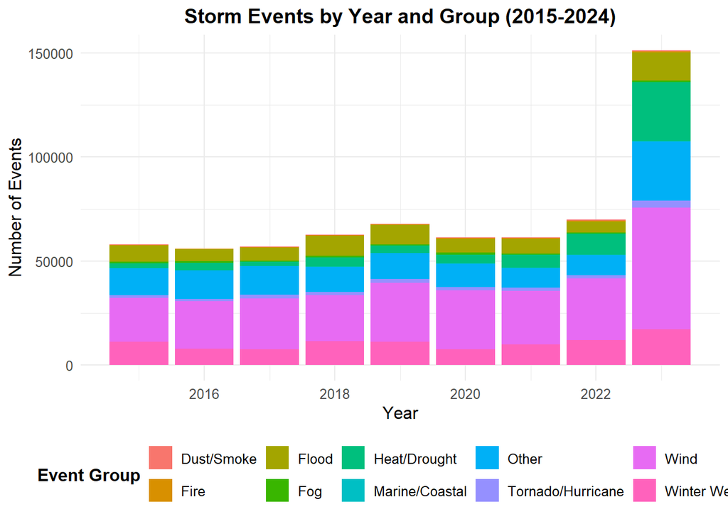

```r
ggplot(events_by_year_group, aes(x = YEAR, y = Event_Count, fill = EVENT_GROUP)) +
  geom_bar(stat = "identity", position = "stack") +
  labs(title = "Storm Events by Year and Group (2015-2024)",
       x = "Year", y = "Number of Events",
       fill = "Event Group") +
  theme_minimal() +
  theme(legend.position = "bottom",
        text = element_text(size = 12),
        legend.title = element_text(face = "bold"),
        plot.title = element_text(face = "bold", size = 14, hjust = 0.5))
```

Fig 1. Storm Events by Year and Group (2015-2024).

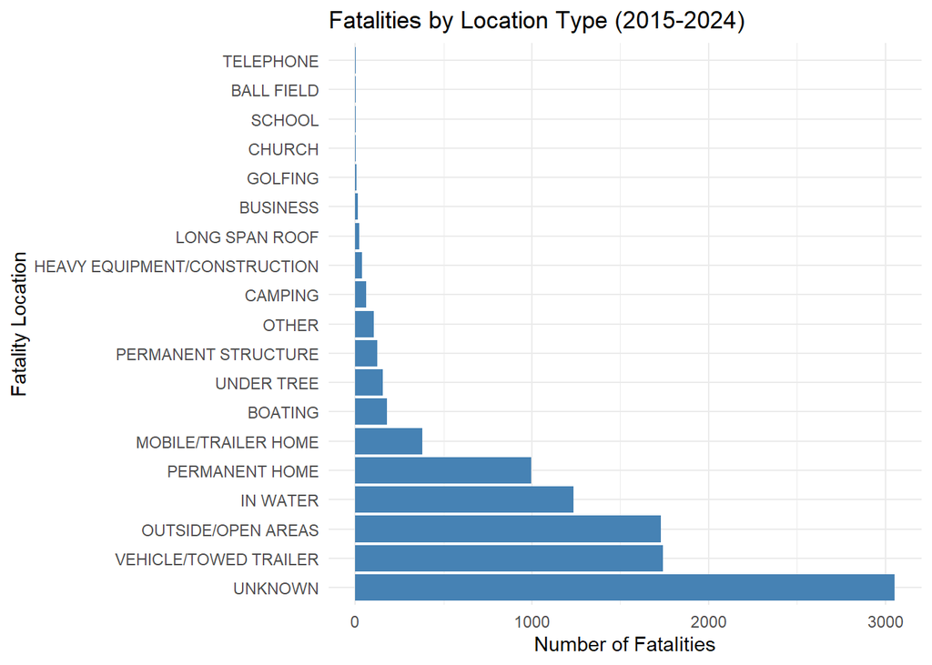

```r
# Summarize fatalities by location
fatalities_by_location <- F_all %>%
  group_by(FATALITY_LOCATION) %>%
  summarise(Fatality_Count = n()) %>%
  ungroup()

#  Fatalities by Location Type
ggplot(fatalities_by_location, aes(x = reorder(FATALITY_LOCATION, -Fatality_Count), y = Fatality_Count)) +
  geom_bar(stat = "identity", fill = "steelblue") +
  labs(title = "Fatalities by Location Type (2015-2024)",
       x = "Fatality Location", y = "Number of Fatalities") +
  theme_minimal() +
  coord_flip()
```

Fig 2. Fatalities by Location Type.

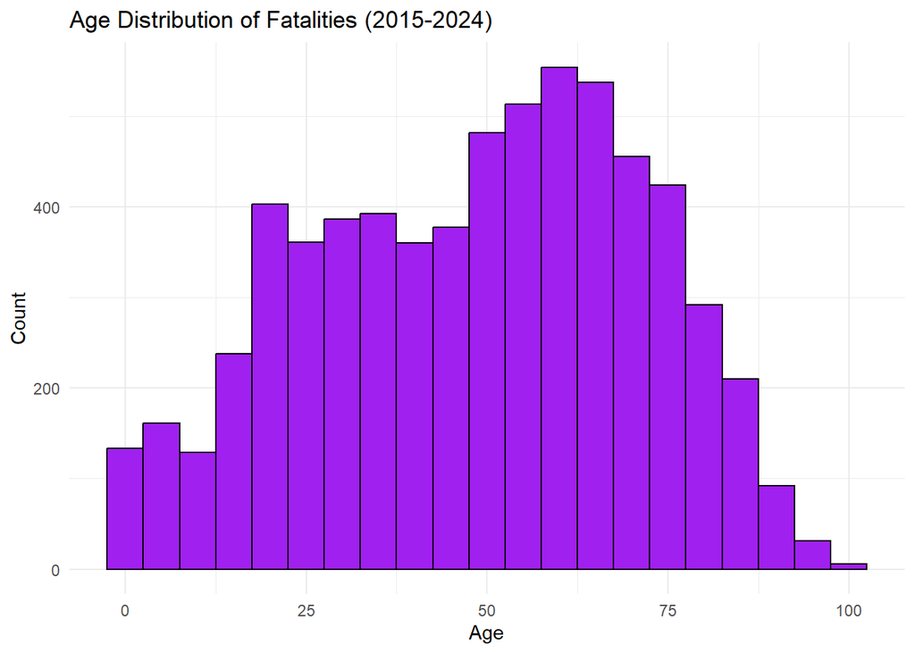

```r
ggplot(F_all, aes(x = FATALITY_AGE)) +
  geom_histogram(binwidth = 5, fill = "purple", color = "black") +
  labs(title = "Age Distribution of Fatalities (2015-2024)",
       x = "Age", y = "Count") +
  theme_minimal()
```

Fig 3. age distribution of fatalities.

```r
event_type_mapping <- D_all %>%
  distinct(EVENT_TYPE) %>%
  mutate(
    EVENT_GROUP = case_when(
      grepl("Flood|Flash Flood|Coastal Flood|Lakeshore Flood", EVENT_TYPE, ignore.case = TRUE) ~ "Flood",
      grepl("Wind|Thunderstorm Wind|Strong Wind|High Wind|Marine High Wind|Marine Strong Wind|Tropical Storm", EVENT_TYPE, ignore.case = TRUE) ~ "Wind",
      grepl("Tornado|Hurricane|Typhoon|Tropical Depression", EVENT_TYPE, ignore.case = TRUE) ~ "Tornado/Hurricane",
      grepl("Snow|Winter|Blizzard|Sleet|Ice Storm|Freezing Fog", EVENT_TYPE, ignore.case = TRUE) ~ "Winter Weather",
      grepl("Heat|Excessive Heat|Drought", EVENT_TYPE, ignore.case = TRUE) ~ "Heat/Drought",
      grepl("Fire|Wildfire", EVENT_TYPE, ignore.case = TRUE) ~ "Fire",
      grepl("Fog|Dense Fog|Marine Dense Fog", EVENT_TYPE, ignore.case = TRUE) ~ "Fog",
      grepl("Dust|Debris", EVENT_TYPE, ignore.case = TRUE) ~ "Dust/Smoke",
      grepl("Tsunami|Seiche|Rip Current|Marine", EVENT_TYPE, ignore.case = TRUE) ~ "Marine/Coastal",
      TRUE ~ "Other"
    )
  )


# Merge event_type_mapping with D_all using left_join
D_all_with_groups <- D_all %>%
  left_join(event_type_mapping, by = "EVENT_TYPE")


#  Create a function to convert "K", "M", "B" to numeric
convert_damage <- function(damage_str) {
  damage_str <- toupper(trimws(damage_str))
  damage_str <- gsub(",", "", damage_str)  # remove commas

  value <- as.numeric(gsub("[KMB]", "", damage_str))

  multiplier <- case_when(
    grepl("K$", damage_str) ~ 1e3,
    grepl("M$", damage_str) ~ 1e6,
    grepl("B$", damage_str) ~ 1e9,
    TRUE ~ 1
  )

  return(value * multiplier)
}
```

Table 1. Summary table of injuries, deaths, and damages by event type.

```r
# Clean the dataset and summarize
impact_summary <- D_all_with_groups%>%
  mutate(

    DAMAGE_PROPERTY_NUM = convert_damage(DAMAGE_PROPERTY),
    DAMAGE_CROPS_NUM = convert_damage(DAMAGE_CROPS)
  ) %>%
  group_by(EVENT_GROUP.x) %>%
  summarise(
    Total_Injuries = sum(INJURIES_DIRECT, na.rm = TRUE) + sum(INJURIES_INDIRECT, na.rm = TRUE),
    Total_Deaths = sum(DEATHS_DIRECT, na.rm = TRUE) + sum(DEATHS_INDIRECT, na.rm = TRUE),
    Total_Damage_Property = sum(DAMAGE_PROPERTY_NUM, na.rm = TRUE),
    Total_Damage_Crops = sum(DAMAGE_CROPS_NUM, na.rm = TRUE)
  ) %>%
  ungroup() %>%
  arrange(desc(Total_Deaths))


datatable(impact_summary,
          options = list(pageLength = 10),
          class = "display",
          filter = "top",
          caption = "Summary of injuries, deaths, and damages by event type",
          escape = TRUE)
```

|  | EVENT_GROUP.x | Total_Injuries | Total_Deaths | Total_Damage_Property | Total_Damage_Crops |
| --- | --- | --- | --- | --- | --- |
| 1 | Heat/Drought | 6411 | 4205 | 28992000 | 2219649250 |
| 2 | Wind | 2430 | 1289 | 18348409950 | 1689863130 |
| 3 | Flood | 379 | 1130 | 92170654760 | 2742437050 |
| 4 | Winter Weather | 3474 | 799 | 1700464540 | 2626000 |
| 5 | Tornado/Hurricane | 6814 | 797 | 79298990490 | 5547278700 |
| 6 | Marine/Coastal | 358 | 684 | 9610000 | 10000 |
| 7 | Other | 1522 | 592 | 20006122190 | 1780934900 |
| 8 | Fire | 813 | 449 | 34241048050 | 8152200 |
| 9 | Fog | 462 | 138 | 19353000 | 0 |
| 10 | Dust/Smoke | 426 | 98 | 904836980 | 34200 |

```r
# Plot fatalities by year
F_all <- F_all %>%
  mutate(Year = as.integer(substr(FAT_YEARMONTH, 1, 4)))
F_all_filtered <- F_all %>%
  filter(Year != 9999 & !is.na(Year))%>% filter(!is.na(FATALITY_SEX))
```

The number of fatalities was lowest in 2019 and highest in 2024 due to all weather disasters in United States (Fig. 4).

Fig 4. Total Fatalities by Year due to all events.

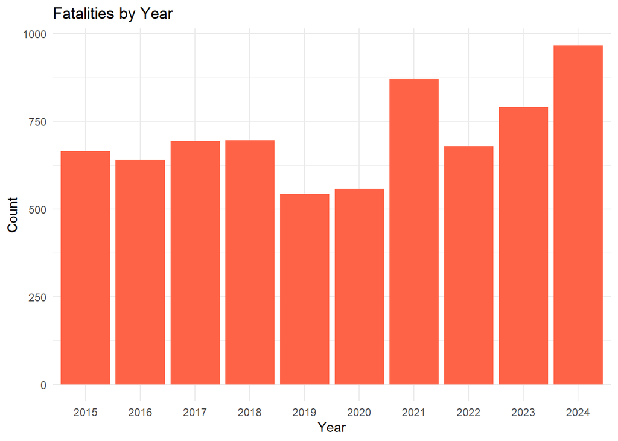

```r
ggplot(F_all_filtered, aes(x = as.factor(Year))) +
  geom_bar(fill = "tomato") +
  labs(title = "Fatalities by Year", x = "Year", y = "Count") +
  theme_minimal()
```

Fig 5. Fatality Age Distribution by Sex and Year.

```r
# Step 1: Extract Year from EVENT_YEARMONTH
F_all <- F_all %>%
  mutate(Year = substr(as.character(EVENT_YEARMONTH), 1, 4),
         FATALITY_AGE = as.numeric(FATALITY_AGE))
F_all_filtered <- F_all %>%
  filter(Year != 9999 & !is.na(Year)) %>%
  filter(Year >= 2015 & Year <= 2024 & !is.na(Year)) %>%
  filter(!is.na(FATALITY_SEX) & FATALITY_SEX != "NA")
```

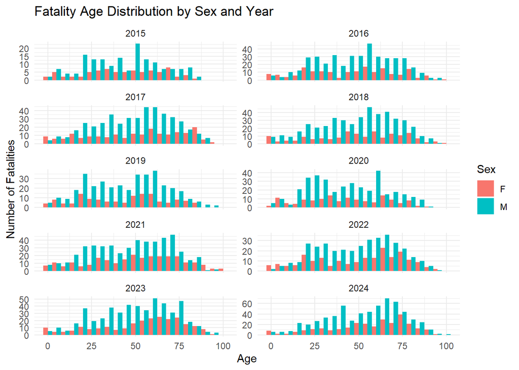

```r
ggplot(F_all_filtered, aes(x = FATALITY_AGE, fill = FATALITY_SEX)) +
  geom_histogram(binwidth = 5, position = "dodge", na.rm = TRUE) +
  facet_wrap(~ Year, scales = "free_y", nrow = 5, ncol = 2) +
  labs(title = "Fatality Age Distribution by Sex and Year",
       x = "Age", y = "Number of Fatalities", fill = "Sex") +
  theme_minimal()
```

## 3 **Hurricane**

```r
##Plot the number of hurricanes by year etc.
library(dplyr)
library(ggplot2)

# Filter for Hurricane events only
hurricane_data <- D_all %>%
  filter(EVENT_TYPE == "Hurricane") %>%
  mutate(YEAR = as.numeric(YEAR))  # make sure it's numeric

# Count number of hurricanes by year and state
hurricane_count <- hurricane_data %>%
  group_by(YEAR, STATE) %>% filter(!STATE %in% places_to_remove) %>%
  summarise(count = n(), .groups = "drop")
```

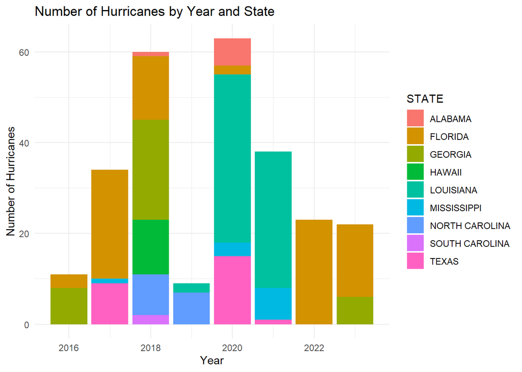

```r
ggplot(hurricane_count, aes(x = YEAR, y = count, fill = STATE)) +
  geom_col(position = "stack") +
  labs(title = "Number of Hurricanes by Year and State",
       x = "Year", y = "Number of Hurricanes") +
  theme_minimal()
```

Fig 6. Number of Hurricanes by Year and State.

```r
# Filter hurricane events and clean DAMAGE_PROPERTIS column
convert_damage <- function(damage_str) {
  damage_str <- toupper(trimws(damage_str))
  damage_str <- gsub(",", "", damage_str)  # remove commas

  value <- as.numeric(gsub("[KMB]", "", damage_str))

  multiplier <- case_when(
    grepl("K$", damage_str) ~ 1e3,
    grepl("M$", damage_str) ~ 1e6,
    grepl("B$", damage_str) ~ 1e9,
    TRUE ~ 1
  )

  return(value * multiplier)
}


hurricane_damage <- D_all %>%
  filter(EVENT_TYPE == "Hurricane") %>%
  mutate(
    EVENT_YEAR = as.numeric(YEAR),
    DAMAGE_PROPERTY_NUM = convert_damage(DAMAGE_PROPERTY)
  )

#  Summarize total damage by year
yearly_damage_Hurricane <- hurricane_damage %>%
  group_by(EVENT_YEAR) %>%
  summarise(total_damage = sum(DAMAGE_PROPERTY_NUM, na.rm = TRUE), .groups = "drop")
```

The highest damages occurred in 2020 and 2022, each exceeding $15 billion, indicating the severity of hurricanes during those years (Fig. 7). In contrast, 2016 experienced minimal damage, suggesting weaker storms or fewer landfalls. Overall, the data suggested significant year-to-year variation in the financial impact of hurricanes.

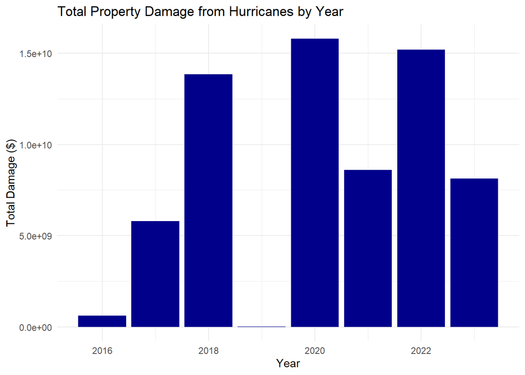

```r
ggplot(yearly_damage_Hurricane, aes(x = EVENT_YEAR, y = total_damage)) +
  geom_col(fill = "darkblue") +
  labs(title = "Total Property Damage from Hurricanes by Year",
       x = "Year", y = "Total Damage ($)") +

  theme_minimal()
```

Fig 7. Total Property Damage from Hurricanes by Year.

```r
#Table Summary of Hazardous (Hurricane) Weather Fatalities(DEATHS_DIRECT + DEATHS_INDIRECT),
#Injuries (INJURIES_DIRECT + INJURIES_INDIRECT) , and Damage Costs(DAMAGE_PROPERTY, DAMAGE_CROP) Listed by State (STATE)

places_to_remove <- c(
  "VIRGIN ISLANDS", "PUERTO RICO", "ST LAWRENCE R", "LAKE ONTARIO",
  "LAKE ST CLAIR", "LAKE SUPERIOR", "HAWAII WATERS", "LAKE ERIE",
  "LAKE HURON", "LAKE MICHIGAN", "DISTRICT OF COLUMBIA", "E PACIFIC",
  "GUAM WATERS", "GULF OF ALASKA", "GULF OF MEXICO", "AMERICAN SAMOA",
  "ATLANTIC NORTH", "ATLANTIC SOUTH", "GUAM"
)

Storms_all <- D_all %>%  filter(!STATE %in% places_to_remove) %>%
  mutate(
    DAMAGE_PROPERTY_NUM = convert_damage(DAMAGE_PROPERTY),
    DAMAGE_CROP_NUM = convert_damage(DAMAGE_CROPS)
  )


#Summarize by State
summary_table_Hurricane <- Storms_all %>%
  group_by(STATE) %>%
  summarise(
    Total_Fatalities = sum(DEATHS_DIRECT + DEATHS_INDIRECT, na.rm = TRUE),
    Total_Injuries = sum(INJURIES_DIRECT + INJURIES_INDIRECT, na.rm = TRUE),
    Total_Property_Damage = sum(DAMAGE_PROPERTY_NUM, na.rm = TRUE),
    Total_Crop_Damage = sum(DAMAGE_CROP_NUM, na.rm = TRUE),
    .groups = "drop"
  )
```

[figure not shown]

```r
#Plot Total Fatalities by State
# Filter out states > 50 fatalities
summary_filtered <- summary_table_Hurricane %>%
  filter(!STATE %in% places_to_remove) %>%
  filter(Total_Fatalities > 50)

# Plot
ggplot(summary_filtered, aes(x = reorder(STATE, Total_Fatalities), y = Total_Fatalities)) +
  geom_col(fill = "firebrick") +
  labs(title = "Total Fatalities by State due to Hurricane",
       x = "State", y = "Fatalities") +
  theme_minimal() +
  theme(axis.text.x = element_text(angle = 45, hjust = 1))
```

[figure not shown]

```r
#Plot Total Injuries by State
# Filter out states > 50 fatalities
summary_filtered <- summary_table_Hurricane %>%
  filter(!STATE %in% places_to_remove) %>%
  filter(Total_Injuries > 50)

# Plot
ggplot(summary_filtered, aes(x = reorder(STATE, Total_Injuries), y = Total_Injuries)) +
  geom_col(fill = "firebrick") +
  labs(title = "Total Injuries by State due to Hurricane",
       x = "State", y = "Injuries") +
  theme_minimal() +
  theme(axis.text.x = element_text(angle = 45, hjust = 1))
```

[figure not shown]

```r
#Total Property Damage by State by Hurricane
summary_filtered <- summary_table_Hurricane %>%
  filter(!STATE %in% places_to_remove) %>%
  filter(Total_Property_Damage > 100000000)

ggplot(summary_filtered, aes(x = reorder(STATE, Total_Property_Damage), y = Total_Property_Damage)) +
  geom_col(fill = "steelblue") +
  labs(title = "Total Property Damage by State due to Hurricane",
       x = "State", y = "Property Damage ($)") +
  theme_minimal() +
  theme(axis.text.x = element_text(angle = 45, hjust = 1))
```

[figure not shown]

```r
#Total crop damage by state (Hurricane)
summary_filtered <- summary_table_Hurricane%>%
  filter(!STATE %in% places_to_remove) %>%
  filter(Total_Crop_Damage > 10000000)

ggplot(summary_filtered, aes(x = reorder(STATE, Total_Crop_Damage), y = Total_Crop_Damage)) +
  geom_col(fill = "steelblue") +
  labs(title = "Total Crop Damage by State due to Hurricane",
       x = "State", y = "Crop Damage ($)") +
  theme_minimal() +
  theme(axis.text.x = element_text(angle = 45, hjust = 1))
```

## 4 **Heavy Snow**

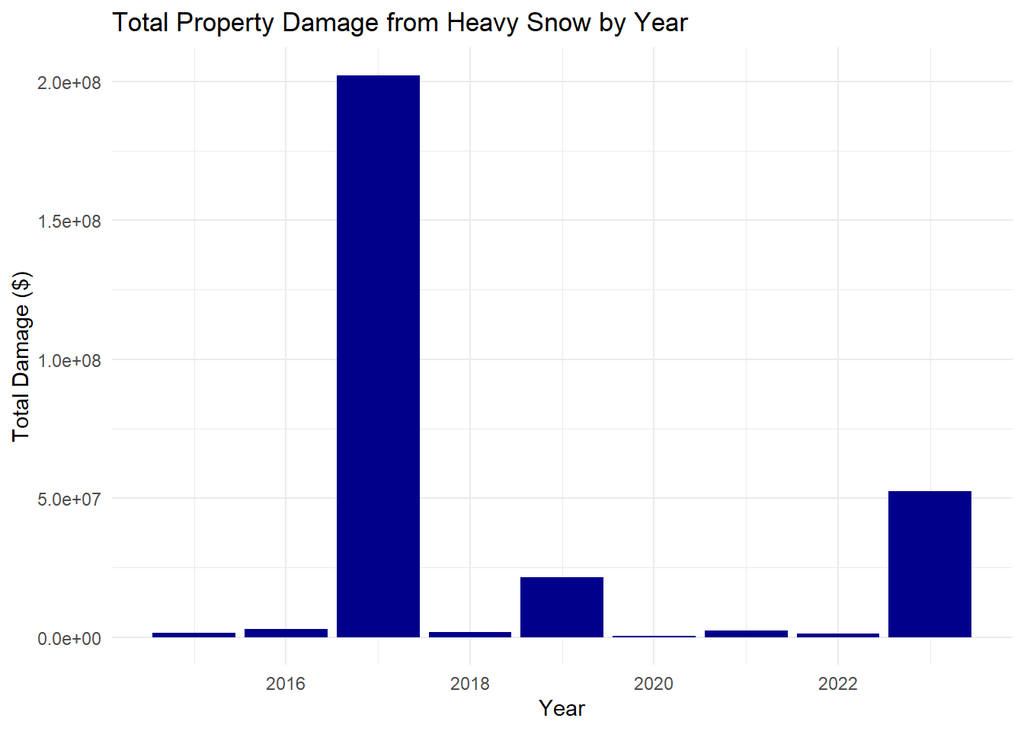

```r
Snow_damage <- D_all %>%
  filter(EVENT_TYPE == "Heavy Snow") %>%
  mutate(
    EVENT_YEAR = as.numeric(YEAR),
    DAMAGE_PROPERTY_NUM = convert_damage(DAMAGE_PROPERTY)
  )



yearly_damage_Snow <- Snow_damage %>%
  group_by(EVENT_YEAR) %>%
  summarise(total_damage = sum(DAMAGE_PROPERTY_NUM, na.rm = TRUE), .groups = "drop")


ggplot(yearly_damage_Snow, aes(x = EVENT_YEAR, y = total_damage)) +
  geom_col(fill = "darkblue") +
  labs(title = "Total Property Damage from Heavy Snow by Year",
       x = "Year", y = "Total Damage ($)") +

  theme_minimal()
```

Fig 12. Total Property Damage from Heavy Snow by Year.

```r
Snow_damage <- Snow_damage %>%
  mutate(
    DAMAGE_PROPERTY_NUM = convert_damage(DAMAGE_PROPERTY),
    DAMAGE_CROP_NUM = convert_damage(DAMAGE_CROPS)
  )

# Summary table for heavy snow data
#Summarize by State
summary_table_snow <- Snow_damage %>% filter(!STATE %in% places_to_remove) %>%
  group_by(STATE) %>%
  summarise(
    Total_Fatalities = sum(DEATHS_DIRECT + DEATHS_INDIRECT, na.rm = TRUE),
    Total_Injuries = sum(INJURIES_DIRECT + INJURIES_INDIRECT, na.rm = TRUE),
    Total_Property_Damage = sum(DAMAGE_PROPERTY_NUM, na.rm = TRUE),
    Total_Crop_Damage = sum(DAMAGE_CROP_NUM, na.rm = TRUE),
    .groups = "drop"
  )
```

Minnesota, Washington and California has highest fatalities in 10 years due to heavy snow event (Fig. 12).

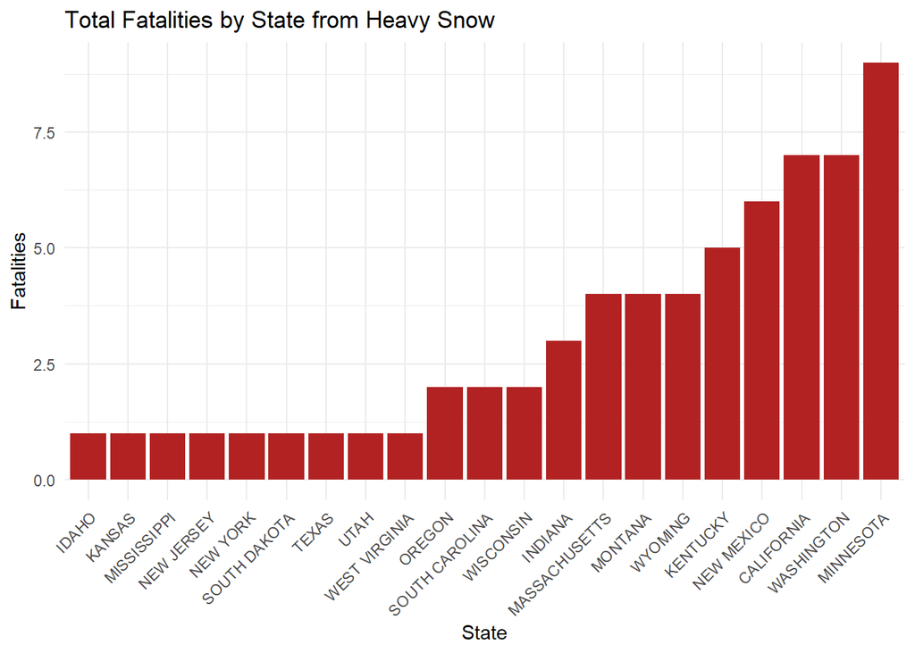

```r
# Filter out states > 0 fatalities
summary_filtered <- summary_table_snow %>%
  filter(!STATE %in% places_to_remove) %>%
  filter(Total_Fatalities > 0)


ggplot(summary_filtered, aes(x = reorder(STATE, Total_Fatalities), y = Total_Fatalities)) +
  geom_col(fill = "firebrick") +
  labs(title = "Total Fatalities by State from Heavy Snow",
       x = "State", y = "Fatalities") +
  theme_minimal() +
  theme(axis.text.x = element_text(angle = 45, hjust = 1))
```

Figure 12. Total Fatalities by State from Heavy Snow.

New Mexico, Arizona, and Indiana Has more injuries event in 10 years due to Heavy Snow(Fig. 13).

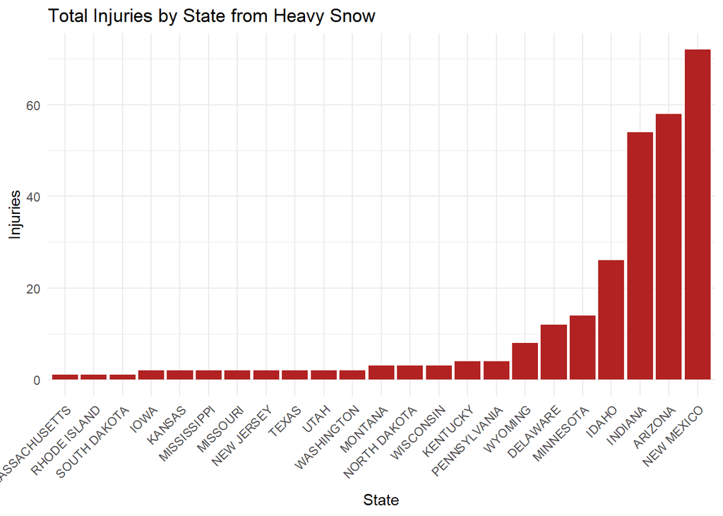

```r
# Filter out states > 0 Injury
summary_filtered <- summary_table_snow %>%
   filter(!STATE %in% places_to_remove) %>%
  filter(Total_Injuries > 0)


ggplot(summary_filtered, aes(x = reorder(STATE, Total_Injuries), y = Total_Injuries)) +
  geom_col(fill = "firebrick") +
  labs(title = "Total Injuries by State from Heavy Snow",
       x = "State", y = "Injuries") +
  theme_minimal() +
  theme(axis.text.x = element_text(angle = 45, hjust = 1))
```

Figure 13. Total Injuries by State from Heavy Snow

Oregon, Idaho had more property damage due to Heavy Snow in 10 years (Fig. 14)

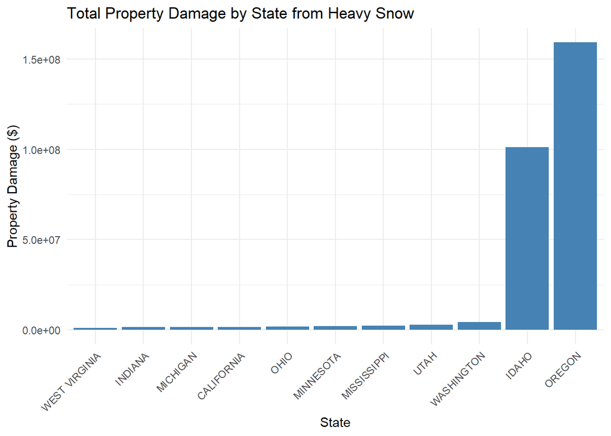

```r
#Total Property Damage by State by Heavy Snow
summary_filtered <- summary_table_snow %>%

  filter(Total_Property_Damage > 1000000)

ggplot(summary_filtered, aes(x = reorder(STATE, Total_Property_Damage), y = Total_Property_Damage)) +
  geom_col(fill = "steelblue") +
  labs(title = "Total Property Damage by State from Heavy Snow",
       x = "State", y = "Property Damage ($)") +
  theme_minimal() +
  theme(axis.text.x = element_text(angle = 45, hjust = 1))
```

Figure 14. Total Property Damage by State from Heavy Snow.

Only two states has crop damage data in 10 years (Fig. 15).

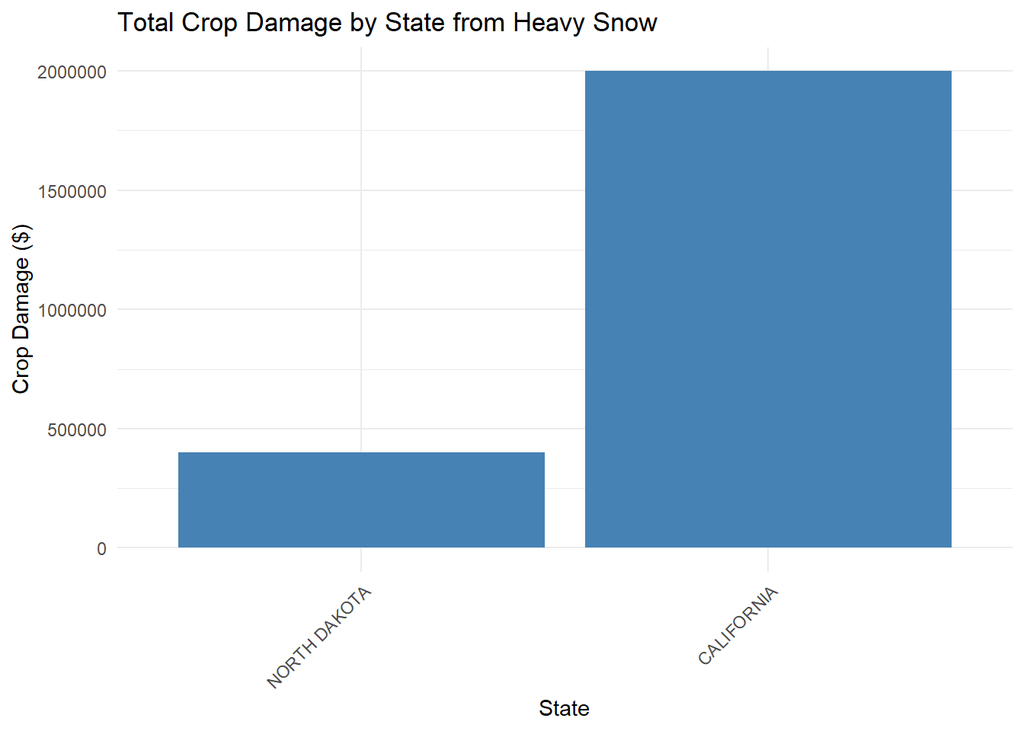

```r
#Total crop damage by state from Heavy snow
summary_filtered_snow <- summary_table_snow %>%
  filter(Total_Crop_Damage > 0)

ggplot(summary_filtered_snow, aes(x = reorder(STATE, Total_Crop_Damage), y = Total_Crop_Damage)) +
  geom_col(fill = "steelblue") +
  labs(title = "Total Crop Damage by State from Heavy Snow",
       x = "State", y = "Crop Damage ($)") +
  theme_minimal() +
  theme(axis.text.x = element_text(angle = 45, hjust = 1))
```

Fig 15. Total Crop Damage by State from Heavy Snow.

## 5 **Tornado**

```r
# summary table for Tornado from 2015 to 2024
Tornado_damage <- D_all %>%
  filter(EVENT_TYPE == "Tornado") %>%
  mutate(
    EVENT_YEAR = as.numeric(YEAR),
    DAMAGE_PROPERTY_NUM = convert_damage(DAMAGE_PROPERTY)
  )

Tornado_damage <- Tornado_damage %>%
  mutate(
    DAMAGE_PROPERTY_NUM = convert_damage(DAMAGE_PROPERTY),
    DAMAGE_CROP_NUM = convert_damage(DAMAGE_CROPS)
  )

#Summarize by State
summary_table_Tornado <- Tornado_damage %>%
  filter(!STATE %in% places_to_remove) %>%
  group_by(STATE) %>%
  summarise(
    Total_Fatalities = sum(DEATHS_DIRECT + DEATHS_INDIRECT, na.rm = TRUE),
    Total_Injuries = sum(INJURIES_DIRECT + INJURIES_INDIRECT, na.rm = TRUE),
    Total_Property_Damage = sum(DAMAGE_PROPERTY_NUM, na.rm = TRUE),
    Total_Crop_Damage = sum(DAMAGE_CROP_NUM, na.rm = TRUE),
    .groups = "drop"
  )
```

Mississippi, Kentucky, and Tennessee has highest fatalities happen due to Tornado in 10 years (Fig. 16).

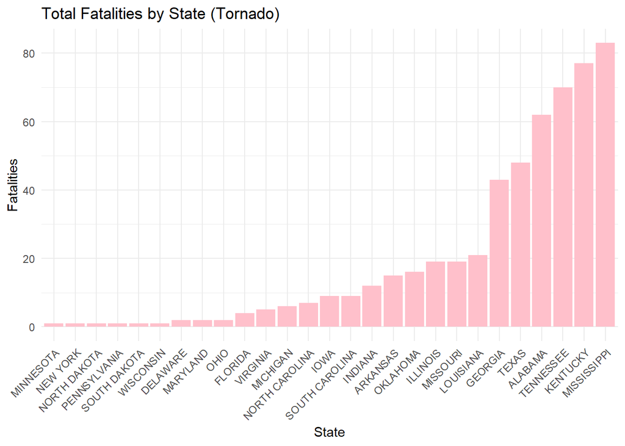

```r
#Plot Total Fatalities by State for Tornado
# Filter out states > 0 fatalities
summary_filtered <- summary_table_Tornado %>%
  filter(Total_Fatalities > 0)

ggplot(summary_filtered, aes(x = reorder(STATE, Total_Fatalities), y = Total_Fatalities)) +
  geom_col(fill = "pink") +
  labs(title = "Total Fatalities by State (Tornado)",
       x = "State", y = "Fatalities") +
  theme_minimal() +
  theme(axis.text.x = element_text(angle = 45, hjust = 1))
```

Fig 16. Total Fatalities by State (Tornado).

Texas, Mississippi and Tennessee had the highest injuries due to Tornado in 10 years (Fig. 17).

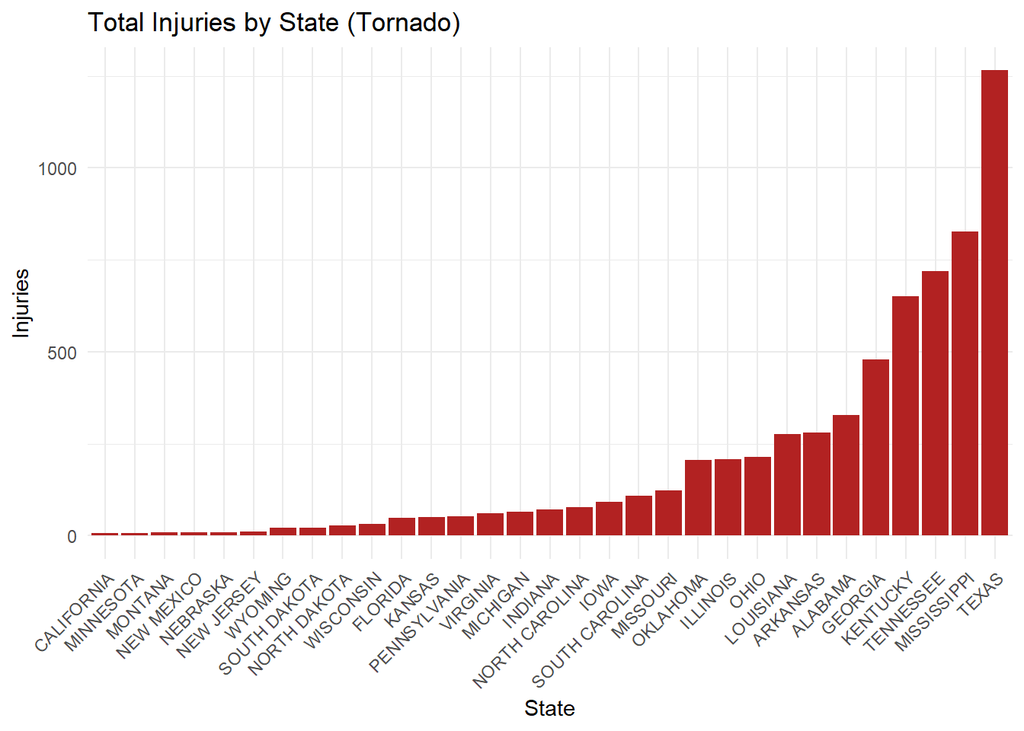

```r
#Plot Total Injuries by State by Tornado
# Filter out states > 5 injuries
summary_filtered <- summary_table_Tornado %>%
  filter(Total_Injuries > 5)

# Plot
ggplot(summary_filtered, aes(x = reorder(STATE, Total_Injuries), y = Total_Injuries)) +
  geom_col(fill = "firebrick") +
  labs(title = "Total Injuries by State (Tornado)",
       x = "State", y = "Injuries") +
  theme_minimal() +
  theme(axis.text.x = element_text(angle = 45, hjust = 1))
```

Fig 17. Total Injuries by State (Tornado).

Texas, Tennessee and Arkansas has highest property damage due to tornado (Fig. 18).

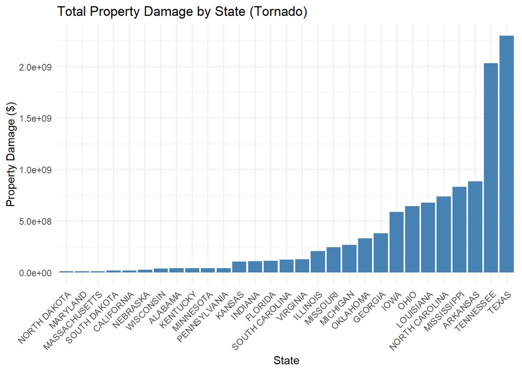

```r
#Total Property Damage by State by Tornado
summary_filtered <- summary_table_Tornado %>%
  filter(Total_Property_Damage > 10000000)

ggplot(summary_filtered, aes(x = reorder(STATE, Total_Property_Damage), y = Total_Property_Damage)) +
  geom_col(fill = "steelblue") +
  labs(title = "Total Property Damage by State (Tornado)",
       x = "State", y = "Property Damage ($)") +
  theme_minimal() +
  theme(axis.text.x = element_text(angle = 45, hjust = 1))
```

Fig 18. Total Property Damage by State (Tornado)

Mississippi had highest crop damage due to Tornado comparing to other states (Fig. 19).

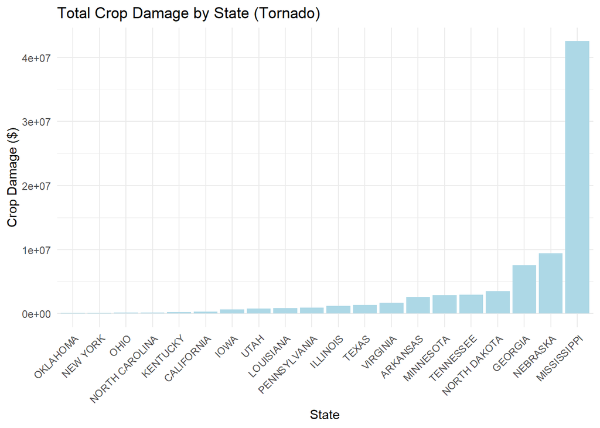

```r
#Total crop damage by state (Tornado)
summary_filtered <- summary_table_Tornado %>%
  filter(Total_Crop_Damage > 100000)

ggplot(summary_filtered, aes(x = reorder(STATE, Total_Crop_Damage), y = Total_Crop_Damage)) +
  geom_col(fill = "lightblue") +
  labs(title = "Total Crop Damage by State (Tornado)",
       x = "State", y = "Crop Damage ($)") +
  theme_minimal() +
  theme(axis.text.x = element_text(angle = 45, hjust = 1))
```

Fig 19. Total Crop Damage by State (Tornado)

In 2020, tornadoes caused the most crop damage in the last 10 years (Fig. 20), while 2018 had the least crop damage during that time.

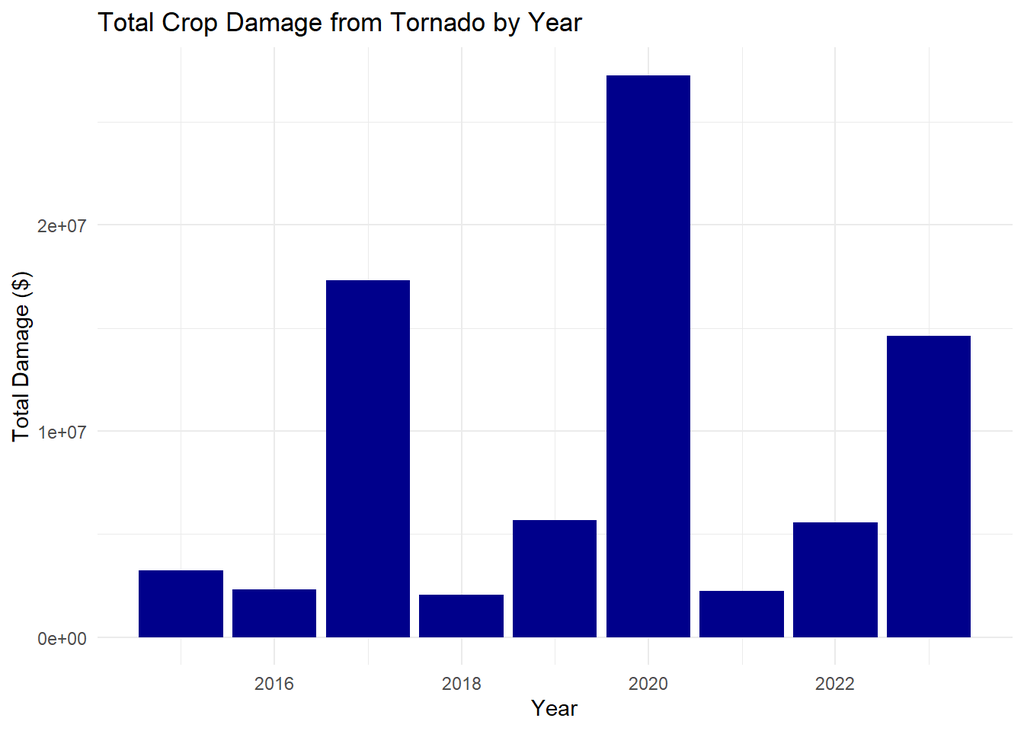

```r
yearly_damage_Tornado <- Tornado_damage %>%
  group_by(EVENT_YEAR) %>%
  summarise(total_damage = sum(DAMAGE_CROP_NUM, na.rm = TRUE), .groups = "drop")

# Step 4: Plot the result
ggplot(yearly_damage_Tornado, aes(x = EVENT_YEAR, y = total_damage)) +
  geom_col(fill = "darkblue") +
  labs(title = "Total Crop Damage from Tornado by Year",
       x = "Year", y = "Total Damage ($)") +

  theme_minimal()
```

Fig 20. Total Crop Damage from Tornado by Year

In 2019, tornadoes caused the most property damage in the last 10 years (Fig. 21), while 2016 had the least property damage during that time.

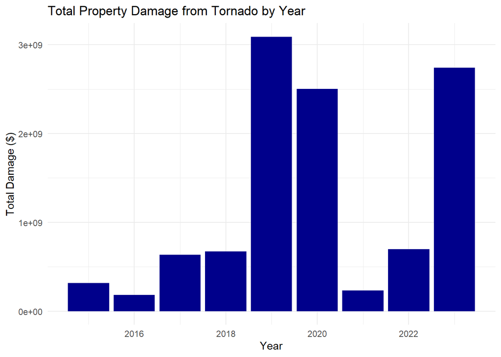

```r
yearly_damage_Tornado <- Tornado_damage %>%
  group_by(EVENT_YEAR) %>%
  summarise(total_damage = sum(DAMAGE_PROPERTY_NUM, na.rm = TRUE), .groups = "drop")

# Step 4: Plot the result
ggplot(yearly_damage_Tornado, aes(x = EVENT_YEAR, y = total_damage)) +
  geom_col(fill = "darkblue") +
  labs(title = "Total Property Damage from Tornado by Year",
       x = "Year", y = "Total Damage ($)") +

  theme_minimal()
```

Fig 21. Total Property Damage from Tornado by Year

## 6 Risk Adjustment by Population

Odds of death and injury normalized by state population.

- Most deadly states for hazardous weather: Arizona, Nevada, Hawaii, South Dakota, and Wyoming.
- Least deadly states for hazardous weather: Massachusetts, Connecticut, D.C., Delaware, and Ohio.
- Most Injurious states for hazardous weather: Wyoming, Mississippi, Oklahoma, Missouri, and Arkansas.
- Least Injurious states for hazardous weather: Connecticut, New York, Massachusetts, Rhode Island, and Vermont.

One primary issue of using absolute numbers is that states with high populations and size may heavily skew the absolute numbers. Upon looking at the initial results, large states with high populations like Texas, Florida, and California were at the top. In order to solve this problem, we can adjust each state by population. We took the United States Census Bureau’s 2020 state populations to get a median population for each state from 2015-2024 assuming no major growth or shrinkage. Given these numbers, we then got the total injuries and fatalities by each state, and divided by population size. This gave us the risk ratio. To ensure the average person could comprehend the total odds and to rank states by safety, we calculated the odds ratios in the format (odds of injury/fatality in each state are *x to 1*).

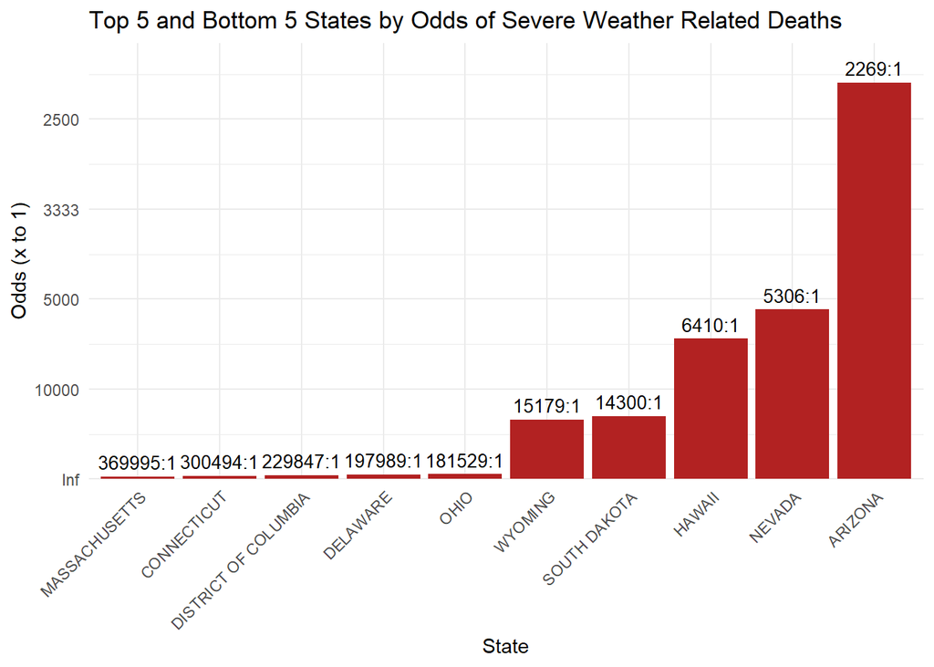

```r
library(DBI)
library(RSQLite)
library(readxl)
library(ggplot2)

con <- dbConnect(RSQLite::SQLite(), "noaa_data_copy.db")
#accesses the noaa_data database
res <- dbSendQuery(con, "
SELECT STATE, SUM(DEATHS_DIRECT + DEATHS_INDIRECT) AS totalDeaths, SUM(INJURIES_DIRECT + INJURIES_INDIRECT ) AS totalInjuries
FROM DETAILS GROUP BY STATE ORDER BY STATE
")
stateData <- dbFetch(res)

dbClearResult(res)
dbDisconnect(con)


statePop <- read_excel("2020_State_Populations.xlsx")


#in the NOAA state column, there are also territories and nautical injuries/deaths
#this ensures we only look at the 50 states and D.C
#may incidentally exclude injuries that are off the coast of states like Alaska or Michigan
unusedStates <- unique(stateData$STATE[!stateData$STATE %in% statePop$STATE])

stateData <- stateData[stateData$STATE %in% statePop$STATE,]

#adds new columns to the statePop data frame
statePop$totalDeaths <- 0
statePop$totalInjuries <- 0


for(i in 1:nrow(statePop)){
  stateName <- statePop$STATE[i]
  matchRow <- stateData[stateData$STATE == stateName,]
  if(nrow(matchRow) > 0){
    statePop$totalDeaths[i] <- matchRow$totalDeaths
    statePop$totalInjuries[i] <- matchRow$totalInjuries
  }
}
#calculates the rate of injury/death in the total state population in 2020 due to recorded
#weather disasters in the NOAA database
statePop$deathRatio <- statePop$totalDeaths/statePop$POPULATION
statePop$injuryRatio <- statePop$totalInjuries/statePop$POPULATION




#calculates an odds ratio using the formula p/(1-p) = odds ratio
#then we look at the odds using 1:x where x is 1/odds
for(i in 1:nrow(statePop)){
  #ensures there a valid ratio that isn't 0
  #saves in the statePop table the raw odds number, then in the 1:x odds format
  if(statePop$deathRatio[i] > 0 && statePop$deathRatio[i]<1){
    statePop$deathOddsNum[i] <- statePop$deathRatio[i]/(1-statePop$deathRatio[i])
    statePop$deathOdds[i] <- paste0("1:", round(1/statePop$deathOddsNum[i]))
  }
  else{
    #if no one died in this state, there is no odds ratio
    statePop$deathOdds[i] <- "None"
  }
  #repeat for injury
  if(statePop$injuryRatio[i] > 0 && statePop$injuryRatio[i]<1){
    statePop$injuryOddsNum[i] <- statePop$injuryRatio[i]/(1-statePop$injuryRatio[i])
    statePop$injuryOdds[i] <- paste0("1:", round(1/statePop$injuryOddsNum[i]))
  }
  else{
    statePop$injuryOdds[i] <- "None"
  }

}
#If we want the top and bottom 5 for odds of death or injury
top5DeathState <- statePop[order(statePop$deathOddsNum), ][1:5, ]
bottom5DeathState <- statePop[order(statePop$deathOddsNum, decreasing=TRUE), ][1:5, ]
top5InjuryState <- statePop[order(statePop$injuryOddsNum), ][1:5, ]
bottom5InjuryState <- statePop[order(statePop$injuryOddsNum, decreasing=TRUE), ][1:5, ]





# combines the top and bottom 5 into one variable to make graphing easier
combinedDeathState <- statePop[which(statePop$STATE %in% c(top5DeathState$STATE,
  bottom5DeathState$STATE)), ]
combinedInjuryState <- statePop[which(statePop$STATE %in% c(top5InjuryState$STATE,
  bottom5InjuryState$STATE)), ]

#Graphs the population adjusted odds of death from the top and bottom 5 states, ordering the y axis so smaller odds are at the bottom (meaning there is a larger x in the formula 1:x)
ggplot(combinedDeathState, aes(x = reorder(STATE, deathOddsNum), y = deathOddsNum)) +
  geom_col(fill = "firebrick") +
  #https://ggplot2.tidyverse.org/reference/geom_text.html
  geom_text(aes(label = paste0(round(1/deathOddsNum), ":1")),
    #The y axis has to be expanded a bit to allow for the odds to be shown at the
    #top of each bar
    vjust = -0.5, size = 3.5) +
  scale_y_continuous(labels = function(x) round(1/x), expand = expansion(mult = c(0, 0.1))) +
  labs(title ="Top 5 and Bottom 5 States by Odds of Severe Weather Related Deaths",
       x = "State", y = "Odds (x to 1)") +theme_minimal() +
  theme(axis.text.x = element_text(angle = 45, hjust = 1))
```

Fig 22. Top and Bottom 5 Most Deadly States for Severe Weather Events Adjusted by Population

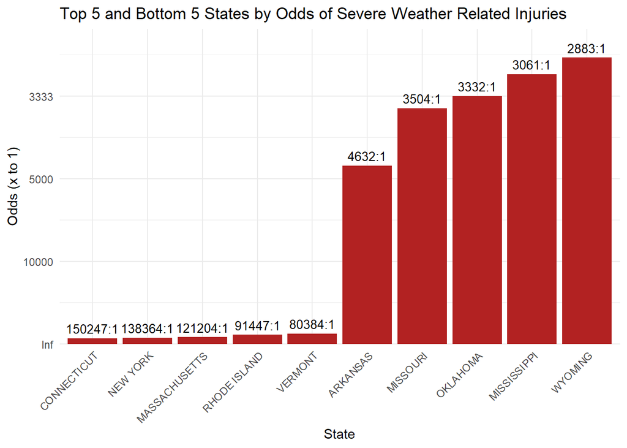

```r
#repeat for injury to get population adjusted odds of injury for the top and bottom states
ggplot(combinedInjuryState, aes(x = reorder(STATE, injuryOddsNum), y = injuryOddsNum)) +
  geom_col(fill = "firebrick") +
  geom_text(aes(label = paste0(round(1/injuryOddsNum), ":1")),
    vjust = -0.5, size = 3.5) +
  scale_y_continuous(labels = function(x) round(1/x), expand = expansion(mult = c(0, 0.1))) +
  labs(title="Top 5 and Bottom 5 States by Odds of Severe Weather Related Injuries",
       x = "State", y= "Odds (x to 1)") +theme_minimal() +
  theme(axis.text.x = element_text(angle = 45, hjust = 1))
```

Fig 23. Top and Bottom 5 Most Injurious States for Severe Weather Events Adjusted by Population

Overall Conclusions: There certainly is a difference in injury and fatality risk by state even when adjusting for population size. Wyoming is among the highest in odds of death and injury for severe weather, a fact that would have never been seen when looking at the absolute numbers. Even small states like Connecticut when adjusted for population size showed that generally, the Northeastern states are far more safe from hazardous weather.

## 7 **Northeastern U.S. states**

```r
# Define Northeastern U.S. states
northeast_states <- c(
  "MAINE", "NEW HAMPSHIRE", "VERMONT", "MASSACHUSETTS",
  "RHODE ISLAND", "CONNECTICUT", "NEW YORK", "NEW JERSEY", "PENNSYLVANIA"
)

# Summarize by STATE for Northeast only
northeast_summary <- Storms_all %>%
  # Filter only northeast region states
  filter(STATE %in% northeast_states) %>%

  # Group by STATE
  group_by(STATE) %>%

  # Summarize impacts
  summarise(
    Total_Fatalities = sum(DEATHS_DIRECT + DEATHS_INDIRECT, na.rm = TRUE),
    Total_Injuries = sum(INJURIES_DIRECT + INJURIES_INDIRECT, na.rm = TRUE),
    Total_Property_Damage = sum(DAMAGE_PROPERTY_NUM, na.rm = TRUE),
    Total_Crop_Damage = sum(DAMAGE_CROP_NUM, na.rm = TRUE),
    .groups = "drop"
  )
```

Table 2. Summarize by STATE for Northeast only

```r
# View the result
datatable(northeast_summary,
          options = list(pageLength = 10),
          class = "display",
          filter = "top",
          caption = "Summarize by STATE for Northeast only",
          escape = TRUE)
```

|  | STATE | Total_Fatalities | Total_Injuries | Total_Property_Damage | Total_Crop_Damage |
| --- | --- | --- | --- | --- | --- |
| 1 | CONNECTICUT | 12 | 24 | 81820910 | 19000 |
| 2 | MAINE | 19 | 75 | 139752000 | 18751000 |
| 3 | MASSACHUSETTS | 19 | 58 | 86486490 | 229250 |
| 4 | NEW HAMPSHIRE | 11 | 53 | 46476000 | 61500000 |
| 5 | NEW JERSEY | 95 | 321 | 304084630 | 13003150 |
| 6 | NEW YORK | 142 | 146 | 876462000 | 1609000 |
| 7 | PENNSYLVANIA | 133 | 472 | 659166890 | 9446540 |
| 8 | RHODE ISLAND | 7 | 12 | 7109400 | 0 |
| 9 | VERMONT | 21 | 8 | 346832500 | 14777000 |

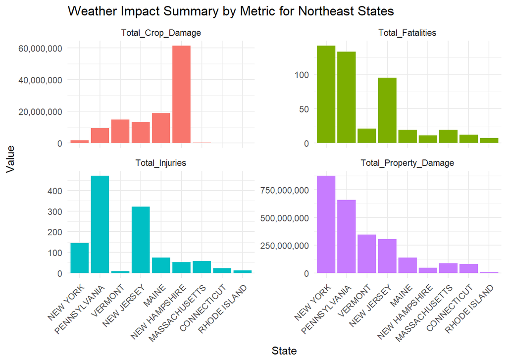

```r
#Side-by-Side Plot: Property vs Crop Damage
library(tidyr)

damage_long <- northeast_summary %>%
  select(STATE, Total_Property_Damage, Total_Crop_Damage) %>%
  pivot_longer(cols = starts_with("Total_"), names_to = "Damage_Type", values_to = "Damage_Value")


#Faceted View: All Four Metrics by State
summary_long <- northeast_summary %>%
  pivot_longer(cols = starts_with("Total_"), names_to = "Metric", values_to = "Value")

ggplot(summary_long, aes(x = reorder(STATE, -Value), y = Value, fill = Metric)) +
  geom_col(show.legend = FALSE) +
  facet_wrap(~ Metric, scales = "free_y") +
  labs(title = "Weather Impact Summary by Metric for Northeast States",
       x = "State", y = "Value") +
  scale_y_continuous(labels = scales::comma_format()) +
  theme_minimal() +
  theme(axis.text.x = element_text(angle = 45, hjust = 1))
```

Fig 24. Weather Impact Summary by Metric for Northeast States

```r
# Summarize by STATE and EVENT_TYPE for Northeast only
northeast_summary_Event <- Storms_all %>%
  # Filter only northeast region states
  filter(STATE %in% northeast_states) %>%

  # Group by STATE and EVENT_TYPE
  group_by(STATE, EVENT_TYPE) %>%

  # Summarize impacts
  summarise(
    Total_Fatalities = sum(DEATHS_DIRECT + DEATHS_INDIRECT, na.rm = TRUE),
    Total_Injuries = sum(INJURIES_DIRECT + INJURIES_INDIRECT, na.rm = TRUE),
    Total_Property_Damage = sum(DAMAGE_PROPERTY_NUM, na.rm = TRUE),
    Total_Crop_Damage = sum(DAMAGE_CROP_NUM, na.rm = TRUE),
    .groups = "drop"
  )
```

When adjusting for population, While New York and Pennsylvania dominate the absolute numbers, the odds of weather related risk in each state become far clearer.

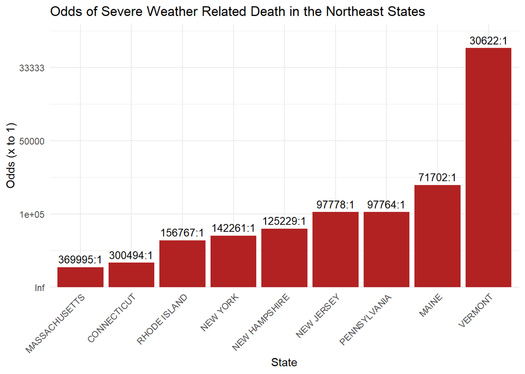

```r
#If we want to look at only Northeastern states, just repeat the previous analysis


northeastStates <- c(
  "MAINE", "NEW HAMPSHIRE", "VERMONT", "MASSACHUSETTS",
  "RHODE ISLAND", "CONNECTICUT", "NEW YORK", "NEW JERSEY", "PENNSYLVANIA"
)
#Groups together all of the northeastern states in one variable
northeastStateData <- statePop[statePop$STATE %in% northeastStates, ]

ggplot(northeastStateData, aes(x = reorder(STATE, deathOddsNum), y = deathOddsNum)) +
  geom_col(fill="firebrick") +
  geom_text(aes(label = paste0(round(1/deathOddsNum), ":1")),
    vjust = -0.5, size = 3.5) +
  scale_y_continuous(labels = function(x) round(1/x), expand = expansion(mult = c(0, 0.1))) +
  labs(title = "Odds of Severe Weather Related Death in the Northeast States",x = "State",
       y = "Odds (x to 1)") + theme_minimal() +
  theme(axis.text.x = element_text(angle = 45, hjust = 1))
```

Fig 25. Odds of Severe Weather Related Death in the Northeast States

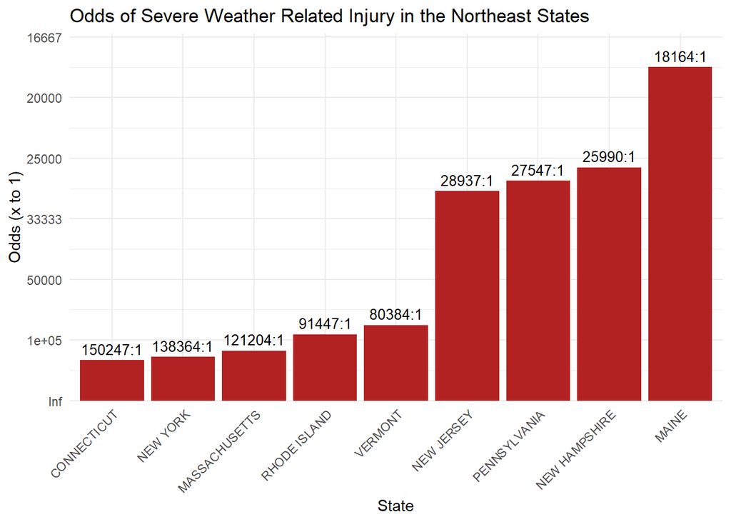

```r
ggplot(northeastStateData, aes(x = reorder(STATE, injuryOddsNum), y = injuryOddsNum)) +
  geom_col(fill="firebrick") +
  geom_text(aes(label = paste0(round(1/injuryOddsNum), ":1")),
    vjust = -0.5, size = 3.5) +
  scale_y_continuous(labels = function(x) round(1/x), expand = expansion(mult = c(0, 0.1))) +
  labs(title = "Odds of Severe Weather Related Injury in the Northeast States",x = "State",
       y = "Odds (x to 1)") + theme_minimal() +
  theme(axis.text.x = element_text(angle = 45, hjust = 1))
```

Fig 26. Odds of Severe Weather Related Injury in the Northeast States

Overall we see that:

- Vermont has far higher fatality risk than other Northeast states.
- Maine, New Hampshire, Pennsylvania, and New Jersey have higher injury rates.
- Total property damage dominated by New York and Pennsylvania due to size.
- Crop damage had very limited reporting, but weather impact in New Hampshire was by far the highest.

## 8 Most Frequent Events

For each month, which event is the most common when adjusting for storm episodes and not events reported?

```r
library(DBI)
library(RSQLite)
library(readxl)
library(ggplot2)
library(dplyr)
library(DT)

#accesses the noaa_data database
con <- dbConnect(RSQLite::SQLite(), "noaa_data_copy.db")

#COMBINED SQL R ANALYSIS
#The SQL query became so convoluted, moving the analysis to R was simpler

#queries for the event type for each month
res <- dbSendQuery(con, "
SELECT MONTH_NAME, EVENT_TYPE, COUNT(DISTINCT EPISODE_ID) AS eventCount
FROM DETAILS
GROUP BY MONTH_NAME, EVENT_TYPE
ORDER BY MONTH_NAME, EVENT_TYPE;
  )
)
ORDER BY D.MONTH_NAME;
")
#stores a table with the count of each event type for each month
monthEvents <- dbFetch(res)

dbClearResult(res)
dbDisconnect(con)

#This R code selects the most common event from each month and puts it in a table
#unique(monthEvents$MONTH_NAME)
#stores the maximum for each month
maxCounts <- tapply(monthEvents$eventCount, monthEvents$MONTH_NAME, max)
#finds the event that corresponds with that maximum
topEvents <- monthEvents[monthEvents$eventCount == maxCounts[monthEvents$MONTH_NAME], ]
#orders by month
topEvents$MONTH_NAME <- factor(topEvents$MONTH_NAME,
  levels = c("January", "February", "March", "April", "May", "June",
             "July", "August", "September", "October", "November", "December"),
  ordered = TRUE)
topEvents <- topEvents[order(topEvents$MONTH_NAME), ]

datatable(topEvents,
          options = list(pageLength = 12),
          class = "display",
          filter = "top",
          caption = "Most Common Weather Event Type per Month (Based on Distinct Episode Count)",
          escape = TRUE)
```

|  | MONTH_NAME | EVENT_TYPE | eventCount |
| --- | --- | --- | --- |
| 214 | January | Winter Weather | 1569 |
| 172 | February | Winter Weather | 1500 |
| 339 | March | Thunderstorm Wind | 1100 |
| 41 | April | Thunderstorm Wind | 1968 |
| 382 | May | Thunderstorm Wind | 3775 |
| 293 | June | Thunderstorm Wind | 5808 |
| 251 | July | Thunderstorm Wind | 6846 |
| 84 | August | Thunderstorm Wind | 4642 |
| 527 | September | Thunderstorm Wind | 1698 |
| 481 | October | Thunderstorm Wind | 646 |

[output cut: 2 more lines]

Table 3. Most Common Weather Event Type per Month

What about the most common in the Northeast?

We can see that the Northeast had:

- One more month of winter weather (March).
- One less month of thunderstorms (October).
- More months of high winds compared to other regions.

```r
library(DBI)
library(RSQLite)
library(readxl)
library(ggplot2)
library(dplyr)
library(DT)

con <- dbConnect(RSQLite::SQLite(), "noaa_data_copy.db")
#Similar analysis for only Northeastern states

#queries for the event type for each month
res <- dbSendQuery(con, "
SELECT MONTH_NAME, EVENT_TYPE, COUNT(DISTINCT EPISODE_ID) AS eventCount
FROM DETAILS
WHERE STATE IN ('MAINE', 'NEW HAMPSHIRE', 'VERMONT', 'MASSACHUSETTS',
                 'RHODE ISLAND', 'CONNECTICUT', 'NEW YORK', 'NEW JERSEY', 'PENNSYLVANIA')
GROUP BY MONTH_NAME, EVENT_TYPE
ORDER BY MONTH_NAME, EVENT_TYPE;
  )
)
ORDER BY D.MONTH_NAME;
")
#stores a table with the count of each event type for each month
monthEvents <- dbFetch(res)

dbClearResult(res)
dbDisconnect(con)

#This R code selects the most common event from each month and puts it in a table
#unique(monthEvents$MONTH_NAME)
#stores the maximum for each month
maxCounts <- tapply(monthEvents$eventCount, monthEvents$MONTH_NAME, max)
#finds the event that corresponds with that maximum
topEvents <- monthEvents[monthEvents$eventCount == maxCounts[monthEvents$MONTH_NAME], ]
#orders by month
topEvents$MONTH_NAME <- factor(topEvents$MONTH_NAME,
  levels = c("January", "February", "March", "April", "May", "June",
             "July", "August", "September", "October", "November", "December"),
  ordered = TRUE)
topEvents <- topEvents[order(topEvents$MONTH_NAME), ]


datatable(topEvents,
          options = list(pageLength = 12),
          class = "display",
          filter = "top",
          caption = "Most Common Northeastern Weather Event Type per Month (Based on Distinct Episode Count)",
          escape = TRUE)
```

|  | MONTH_NAME | EVENT_TYPE | eventCount |
| --- | --- | --- | --- |
| 119 | January | Winter Weather | 244 |
| 93 | February | Winter Weather | 262 |
| 180 | March | Winter Weather | 160 |
| 19 | April | Thunderstorm Wind | 109 |
| 198 | May | Thunderstorm Wind | 281 |
| 153 | June | Thunderstorm Wind | 496 |
| 135 | July | Thunderstorm Wind | 874 |
| 41 | August | Thunderstorm Wind | 609 |
| 262 | September | Thunderstorm Wind | 213 |
| 243 | October | Strong Wind | 84 |

[output cut: 2 more lines]

```r
#From this we can see the northeastern states have one more month of
#common winter weather in March, and one less month of thunderstorms in October
#with the Northeast favoring strong winds
```

Table 4. Most Common Weather Event Type per Month in the Northeast

## 9 Most Hazardous Events

When looking at fatality rate, which events appear to be the most dangerous?

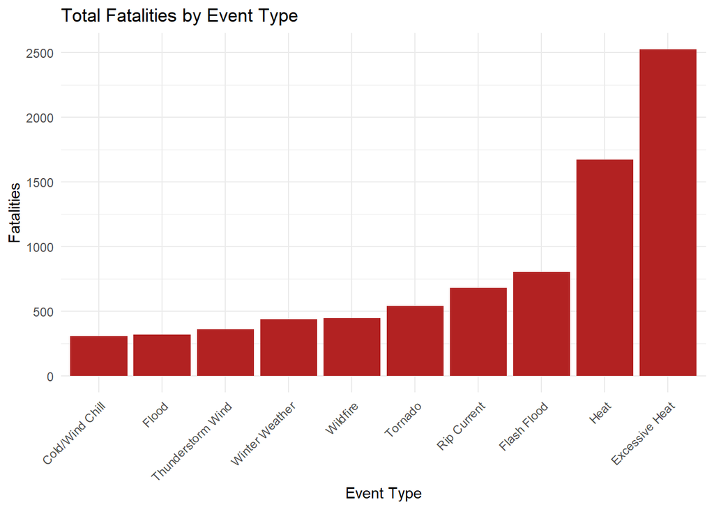

```r
library(DBI)
library(RSQLite)
library(readxl)
library(ggplot2)
library(dplyr)

#accesses the noaa_data database
con <- dbConnect(RSQLite::SQLite(), "noaa_data_copy.db")

#queries the total fatalities for each event type
res <- dbSendQuery(con, "
SELECT DETAILS.EVENT_TYPE, COUNT(FATALITY.FATALITY_ID) AS fatalityCount FROM DETAILS
JOIN FATALITY ON DETAILS.EVENT_ID = FATALITY.EVENT_ID
GROUP BY DETAILS.EVENT_TYPE ORDER BY fatalityCount DESC;
")
#stores results in a table
eventFatality <- dbFetch(res)

dbClearResult(res)
dbDisconnect(con)

#first, select the top 10 event types by fatalities
top10EventFatalities <- eventFatality[1:10, ]
#Now graph those ordered by fatality
ggplot(top10EventFatalities, aes(x = reorder(EVENT_TYPE, fatalityCount), y = fatalityCount)) +
  geom_col(fill = "firebrick") +
  labs(title = "Total Fatalities by Event Type",
       x = "Event Type", y = "Fatalities") +
  theme_minimal() +
  theme(axis.text.x = element_text(angle = 45, hjust = 1))
```

Fig 27. Total Fatalities by Event Type

## 10 Conclusion

This analysis of NOAA weather data from 2015–2024 used R, SQL, and data visualization tools to explore patterns in event frequency, fatalities, injuries, and damages. Results showed that weather-related harm is unevenly distributed across regions, with notable differences in risk once adjusted for population size. Fatalities were more common among men and showed increasing risk in ages 20 and 60-75, while injury and death locations were often outdoors or in vehicles. Event frequency remained generally stable over time with notable spikes for hurricanes, tornadoes, and heavy snow during certain years. Overall, the analysis highlights the importance of context in understanding the true impact of hazardous weather across the United States.

**Appendix**

## 11 Database Design

The Sqlite3 database created to store and query the NOAA provided data contains all information from the Details, Fatality, and Location CSV files provided on their website from 2015-2024. Each category and year came in its own CSV file, and this needed to be combined into a singular entity. In order for the R script to compile, it was necessary to include every category mentioned in the CSV files inside the database. The full database design is listed below:

### 11.1 Populating the Database

To populate the newly created database after it was created using Sqlite3 from a Linux terminal, R was necessary to import everything in an efficient manner. The database called noaa_data_copy.db was moved manually from the Linux server into a folder containing all relevant NOAA CSV files. R code was then utilized with the dbConnect(SQLite(), dbname = “noaa_data_copy.db”) function. Upon creating a method that ensures the code doesn’t break when it found there was missing location data CSV files for certain years with safeReadCsv, using a loop to import all CSV data was simple. The dbWriteTable() function inside the loop that accesses fatality, location, and details CSV files for each year allowed easy importation from CSV to SQL.

SQL Database Design in code chunk below:

```r
CREATE TABLE IF NOT EXISTS [DETAILS] (
  [DETAILS_ID] INTEGER PRIMARY KEY AUTOINCREMENT,
  [BEGIN_YEARMONTH] DATETIME,
  [BEGIN_DAY] DATETIME,
  [BEGIN_TIME] DATETIME,
  [END_YEARMONTH] DATETIME,
  [END_DAY] DATETIME,
  [END_TIME] DATETIME,
  [EPISODE_ID] INTEGER,
  [EVENT_ID] INTEGER NOT NULL,
  [STATE] TEXT,
  [STATE_FIPS] TEXT,
  [YEAR] INTEGER,
  [MONTH_NAME] TEXT,
  [EVENT_TYPE] TEXT,
  [CZ_TYPE] TEXT,
  [CZ_FIPS] INTEGER,
  [CZ_NAME] TEXT,
  [WFO] TEXT,
  [BEGIN_DATE_TIME] DATETIME,
  [CZ_TIMEZONE] TEXT,
  [END_DATE_TIME] DATETIME,
  [INJURIES_DIRECT] INTEGER,
  [INJURIES_INDIRECT] INTEGER,
  [DEATHS_DIRECT] INTEGER,
  [DEATHS_INDIRECT] INTEGER,
  [DAMAGE_PROPERTY] TEXT,
  [DAMAGE_CROPS] TEXT,
  [SOURCE] TEXT,
  [MAGNITUDE] REAL,
  [MAGNITUDE_TYPE] INTEGER,
  [FLOOD_CAUSE] TEXT,
  [CATEGORY] TEXT,
  [TOR_F_SCALE] TEXT,
  [TOR_LENGTH] REAL,
  [TOR_WIDTH] INTEGER,
  [TOR_OTHER_WFO] TEXT,
  [TOR_OTHER_CZ_STATE] TEXT,
  [TOR_OTHER_CZ_FIPS] INTEGER,
  [TOR_OTHER_CZ_NAME] TEXT,
  [BEGIN_RANGE] INTEGER,
  [BEGIN_AZIMUTH] TEXT,
  [BEGIN_LOCATION] TEXT,
  [END_RANGE] INTEGER,
  [END_AZIMUTH] TEXT,
  [END_LOCATION] TEXT,
  [BEGIN_LAT] REAL,
  [BEGIN_LON] REAL,
  [END_LAT] REAL,
  [END_LON] REAL,
  [EPISODE_NARRATIVE] TEXT,
  [EVENT_NARRATIVE] TEXT,
  [DATA_SOURCE] TEXT
);

CREATE TABLE IF NOT EXISTS [LOCATIONS] (
  [LOCATION_ID] INTEGER PRIMARY KEY AUTOINCREMENT,
  [YEARMONTH] INTEGER,
  [EPISODE_ID] INTEGER NOT NULL,
  [LOCATION_INDEX] INTEGER,
  [EVENT_ID] INTEGER NOT NULL,
  [RANGE] REAL,
  [AZIMUTH] TEXT,
  [LOCATION] TEXT,
  [LATITUDE] REAL,
  [LONGITUDE] REAL,
  [LAT2] INTEGER,
  [LON2] INTEGER,
  FOREIGN KEY ([EVENT_ID]) REFERENCES [DETAILS]([EVENT_ID])
);

CREATE TABLE IF NOT EXISTS [FATALITY] (
  [FAT_YEARMONTH] INTEGER,
  [FAT_DAY] INTEGER,
  [FAT_TIME] INTEGER,
  [FATALITY_ID] INTEGER PRIMARY KEY NOT NULL,
  [EVENT_ID] INTEGER NOT NULL,
  [FATALITY_TYPE] TEXT,
  [FATALITY_DATE] DATETIME,
  [FATALITY_AGE] INTEGER,
  [FATALITY_SEX] TEXT,
  [FATALITY_LOCATION] TEXT,
  [EVENT_YEARMONTH] INTEGER,
  FOREIGN KEY ([EVENT_ID]) REFERENCES [DETAILS]([EVENT_ID])
);
```

Data importation:

```r
#This code can only be run once. Any more times and the database will be populated with duplicates.
library(DBI)
library(RSQLite)
library(readr)
library(dplyr)

#UNCOMMENT THE TOP LINE TO RUN THE CODE. DO NOT RUN TWICE
#connects to the database, and begins to read the data
#con <- dbConnect(SQLite(), dbname = "noaa_data_copy.db")
safeReadCsv <- function(fileName){

  #protection against when some of the location data years are not available
  if(file.exists(fileName)){
    read_csv(fileName, show_col_types = FALSE)
  }else{

    message(paste("File can't be found:", fileName))
    return(NULL)
  }
}

#Populates the database using a loop that selects CSV files by year.
#Used the paste0 function to simplify the process of selecting csv files while trying something new.
years <- 2015:2024
for (year in years){
  detailsFile <- paste0("StormEvents_details_", year, ".csv")
  fatalityFile <- paste0("StormEvents_fatalities_", year, ".csv")
  locationFile <- paste0("StormEvents_locations_", year, ".csv")
 detailsData <- safeReadCsv(detailsFile)
  fatalityData <- safeReadCsv(fatalityFile)
  locationData <- safeReadCsv(locationFile)
  #displays discrepancies in format indicating mishandled data
  problems(locationData)
  problems(detailsData)

  #prints a small message in case one of the years has a missing file.
  if (!is.null(detailsData)){
    dbWriteTable(con, "Details", detailsData, append = TRUE)
  }
  if (!is.null(fatalityData)){
    dbWriteTable(con, "Fatality", fatalityData, append = TRUE)
  }
  if (!is.null(locationData)){
    dbWriteTable(con, "Locations", locationData, append = TRUE)
  }
  message(paste("Finished inserting for year:" ,year))
}
```

Once the data was inside the SQL database, the data could be queried to solve select problems, but creating graphs and simplifying the analysis suggested there should also be a copy of the data in an R dataframe. Moving the 3 database tables (details to D_all, fatalities to F_all, and locations to L_all) by SELECT * FROM [table] allows us to create data frames that can be easily accessed in R without the SQL importation.

```r
#Creates a data frame from the SQL database noaa_data_copy for
#the location data
con <- dbConnect(RSQLite::SQLite(), "noaa_data_copy.db")
res <- dbSendQuery(con, "SELECT * FROM LOCATIONS")
L_all <- dbFetch(res)
dbClearResult(res)

#Creates a data frame from the SQL database noaa_data_copy for
#the fatality data
res <- dbSendQuery(con, "SELECT * FROM FATALITY")
F_all <- dbFetch(res)
dbClearResult(res)

#Creates a data frame from the SQL database noaa_data_copy for
#the details data
res <- dbSendQuery(con, "SELECT * FROM DETAILS")
D_all <- dbFetch(res)
dbClearResult(res)
dbDisconnect(con)
```

### 11.2 Data Review

```r
library(DBI)
library(RSQLite)
library(DT)



con <- dbConnect(RSQLite::SQLite(), "noaa_data_copy.db")

# --- DETAILS TABLE ---
res <- dbSendQuery(con, "
SELECT
  DETAILS_ID, BEGIN_YEARMONTH, BEGIN_DAY, BEGIN_TIME, END_YEARMONTH, END_DAY, END_TIME,
  EPISODE_ID, EVENT_ID, STATE, STATE_FIPS, YEAR, MONTH_NAME, EVENT_TYPE,
  CZ_TYPE, CZ_FIPS, CZ_NAME, WFO, BEGIN_DATE_TIME, CZ_TIMEZONE, END_DATE_TIME,
  INJURIES_DIRECT, INJURIES_INDIRECT, DEATHS_DIRECT, DEATHS_INDIRECT,
  DAMAGE_PROPERTY, DAMAGE_CROPS, SOURCE, MAGNITUDE, MAGNITUDE_TYPE,
  FLOOD_CAUSE, CATEGORY, TOR_F_SCALE, TOR_LENGTH, TOR_WIDTH,
  TOR_OTHER_WFO, TOR_OTHER_CZ_STATE, TOR_OTHER_CZ_FIPS, TOR_OTHER_CZ_NAME,
  BEGIN_RANGE, BEGIN_AZIMUTH, BEGIN_LOCATION, END_RANGE, END_AZIMUTH, END_LOCATION,
  BEGIN_LAT, BEGIN_LON, END_LAT, END_LON,
  EPISODE_NARRATIVE, EVENT_NARRATIVE, DATA_SOURCE
FROM DETAILS
LIMIT 3;
")
df1 <- dbFetch(res)
dbClearResult(res)

datatable(
  df1[, !names(df1) %in% c("EPISODE_NARRATIVE", "EVENT_NARRATIVE", "DATA_SOURCE")],
  options = list(pageLength = 10),
  class = "display",
  filter = "top",
  caption = "First 3 entries from DETAILS table (without long narrative fields)",
  escape = TRUE
)
```

|  | DETAILS_ID | BEGIN_YEARMONTH | BEGIN_DAY | BEGIN_TIME | END_YEARMONTH | END_DAY | END_TIME | EPISODE_ID | EVENT_ID | STATE | STATE_FIPS | YEAR | MONTH_NAME | EVENT_TYPE | CZ_TYPE | CZ_FIPS | CZ_NAME | WFO | BEGIN_DATE_TIME | CZ_TIMEZONE | END_DATE_TIME | INJURIES_DIRECT | INJURIES_INDIRECT | DEATHS_DIRECT | DEATHS_INDIRECT | DAMAGE_PROPERTY | DAMAGE_CROPS | SOURCE | MAGNITUDE | … |
| --- | --- | --- | --- | --- | --- | --- | --- | --- | --- | --- | --- | --- | --- | --- | --- | --- | --- | --- | --- | --- | --- | --- | --- | --- | --- | --- | --- | --- | --- | --- |
| 1 | 1 | 201501 | 27 | 1200 | 201501 | 28 | 400 | 92561 | 559139 | NEW HAMPSHIRE | 33.0 | 2015 | January | Winter Storm | Z | 12 | EASTERN HILLSBOROUGH | GYX | 27-JAN-15 12:00:00 | EST-5 | 28-JAN-15 04:00:00 | 0 | 0 | 0 | 0 | 0.00K | 0.00K | Official NWS Observations |  | … |
| 2 | 2 | 201501 | 24 | 700 | 201501 | 24 | 2100 | 92625 | 555067 | NEW HAMPSHIRE | 33.0 | 2015 | January | Heavy Snow | Z | 12 | EASTERN HILLSBOROUGH | GYX | 24-JAN-15 07:00:00 | EST-5 | 24-JAN-15 21:00:00 | 0 | 0 | 0 | 0 | 0.00K | 0.00K | Trained Spotter |  | … |
| 3 | 3 | 201501 | 27 | 600 | 201501 | 27 | 1200 | 92561 | 554564 | NEW HAMPSHIRE | 33.0 | 2015 | January | Blizzard | Z | 12 | EASTERN HILLSBOROUGH | GYX | 27-JAN-15 06:00:00 | EST-5 | 27-JAN-15 12:00:00 | 0 | 0 | 0 | 0 | 0.00K | 0.00K | AWOS |  | … |

```r
# --- LOCATIONS TABLE ---
res <- dbSendQuery(con, "
SELECT
  YEARMONTH, EPISODE_ID, LOCATION_INDEX, EVENT_ID,
  RANGE, AZIMUTH, LOCATION, LATITUDE, LONGITUDE, LAT2, LON2
FROM LOCATIONS
LIMIT 3;
")
df2 <- dbFetch(res)
dbClearResult(res)

datatable(df2,
          options = list(pageLength = 10),
          class = "display",
          filter = "top",
          caption = "First 3 entries from LOCATIONS table",
          escape = TRUE)
```

|  | YEARMONTH | EPISODE_ID | LOCATION_INDEX | EVENT_ID | RANGE | AZIMUTH | LOCATION | LATITUDE | LONGITUDE | LAT2 | LON2 |
| --- | --- | --- | --- | --- | --- | --- | --- | --- | --- | --- | --- |
| 1 | 201512 | 101377 | 1 | 606556 | 10.42 | WNW | VAITOGI | -14.3244 | -170.8347 | -1419464 | 17050082 |
| 2 | 201512 | 101377 | 2 | 606556 | 3.81 | NE | PAGO PAGO | -14.2578 | -170.5634 | -1415468 | 17033804 |
| 3 | 201512 | 101377 | 1 | 606560 | 0 | N | OFU | -14.2 | -169.7 | -1412000 | 16942000 |

```r
# --- FATALITY TABLE ---
res <- dbSendQuery(con, "
SELECT
  FAT_YEARMONTH, FAT_DAY, FAT_TIME, FATALITY_ID, EVENT_ID,
  FATALITY_TYPE, FATALITY_DATE, FATALITY_AGE, FATALITY_SEX,
  FATALITY_LOCATION, EVENT_YEARMONTH
FROM FATALITY
LIMIT 3;
")
df3 <- dbFetch(res)
dbClearResult(res)

datatable(df3,
          options = list(pageLength = 10),
          class = "display",
          filter = "top",
          caption = "First 3 entries from FATALITY table",
          escape = TRUE)
```

|  | FAT_YEARMONTH | FAT_DAY | FAT_TIME | FATALITY_ID | EVENT_ID | FATALITY_TYPE | FATALITY_DATE | FATALITY_AGE | FATALITY_SEX | FATALITY_LOCATION | EVENT_YEARMONTH |
| --- | --- | --- | --- | --- | --- | --- | --- | --- | --- | --- | --- |
| 1 | 201501 | 4 | 0 | 24152 | 547095 | D | 01/04/2015 00:00:00 | 37 | M | Mobile/Trailer Home | 999999 |
| 2 | 201501 | 12 | 0 | 24170 | 548156 | D | 01/12/2015 00:00:00 | 60 | M | Vehicle/Towed Trailer | 999999 |
| 3 | 201501 | 8 | 0 | 24171 | 548238 | D | 01/08/2015 00:00:00 | 76 | F | Outside/Open Areas | 201501 |

```r
dbDisconnect(con)
```

## 12 Data Cleaning

Brief description of data cleaning and aggregation.

The data cleaning and aggregation process was done in several steps. First, the year was extracted from the FAT_EVENTYEAR column. Rows with missing or invalid years and missing sex information were removed. Age values were cleaned by removing non-numeric characters and converting them to numbers. Locations were trimmed, converted to uppercase, and empty values were replaced with “UNKNOWN”. Records from non-continental U.S. areas like “GUAM” and “LAKE MICHIGAN” were excluded.

Next, event types were grouped into broader categories such as “Flood”, “Wind”, and “Winter Weather” based on keywords. A custom function was used to convert damage values with “K”, “M”, or “B” into numeric format. Then, the dataset was grouped by event type. The total number of injuries, deaths, and damage costs were calculated for each group. The final result shows which event types had the greatest impact.

Tools used: R, SQL, ggplot2 for plotting, library(DT) for visualizing tables.

```r
#data cleaning
F_all <- F_all %>%
  # Convert age to numeric, handling non-numeric entries
  mutate(FATALITY_AGE = as.numeric(gsub("[^0-9]", "", FATALITY_AGE))) %>%
  # Clean location data
  mutate(FATALITY_LOCATION = trimws(toupper(FATALITY_LOCATION)),
         FATALITY_LOCATION = ifelse(FATALITY_LOCATION == "", "UNKNOWN", FATALITY_LOCATION))

places_to_remove <- c(
  "VIRGIN ISLANDS", "PUERTO RICO", "ST LAWRENCE R", "LAKE ONTARIO",
  "LAKE ST CLAIR", "LAKE SUPERIOR", "HAWAII WATERS", "LAKE ERIE",
  "LAKE HURON", "LAKE MICHIGAN", "DISTRICT OF COLUMBIA", "E PACIFIC",
  "GUAM WATERS", "GULF OF ALASKA", "GULF OF MEXICO", "AMERICAN SAMOA",
  "ATLANTIC NORTH", "ATLANTIC SOUTH", "GUAM"
)


# Number of Events by Year and Event Type
library(dplyr)
library(ggplot2)
library (DT)

# Group similar events into broader categories
D_all <- D_all %>%
  mutate(EVENT_GROUP = case_when(
    grepl("Flood|Flash Flood|Coastal Flood|Lakeshore Flood", EVENT_TYPE, ignore.case = TRUE) ~ "Flood",
    grepl("Wind|Thunderstorm Wind|Strong Wind|High Wind|Marine High Wind|Marine Strong Wind|Tropical Storm", EVENT_TYPE, ignore.case = TRUE) ~ "Wind",
    grepl("Tornado|Hurricane|Typhoon|Tropical Depression", EVENT_TYPE, ignore.case = TRUE) ~ "Tornado/Hurricane",
    grepl("Snow|Winter|Blizzard|Sleet|Ice Storm|Freezing Fog", EVENT_TYPE, ignore.case = TRUE) ~ "Winter Weather",
    grepl("Heat|Excessive Heat|Drought", EVENT_TYPE, ignore.case = TRUE) ~ "Heat/Drought",
    grepl("Fire|Wildfire", EVENT_TYPE, ignore.case = TRUE) ~ "Fire",
    grepl("Fog|Dense Fog|Marine Dense Fog", EVENT_TYPE, ignore.case = TRUE) ~ "Fog",
    grepl("Dust|Debris", EVENT_TYPE, ignore.case = TRUE) ~ "Dust/Smoke",
    grepl("Tsunami|Seiche|Rip Current|Marine", EVENT_TYPE, ignore.case = TRUE) ~ "Marine/Coastal",
    TRUE ~ "Other"
  ))

# Summarize
events_by_year_group <- D_all %>%
  group_by(YEAR, EVENT_GROUP) %>%
  summarise(Event_Count = n()) %>%
  ungroup()
```

## 13 Summary of Work

Shrijana: Performed significant R analysis and data cleaning. Ensured all quantities in the data were numeric not text, adjusted date formatting, and cleaned location data. Created visually appealing R plots. Analyzed Storm events by year, event trends, fatalities by location, age/sex vs fatality rate, fatalities by year, hurricane/tornado/heavy snow, and property/crop damage. Explained all listed plots in the final report and all related code.

Aidan: Worked with the SQL database design and conversion from SQL to R code. Used SQL queries along with R code to do odds of injury/death adjusted for population generally and in the Northeast, most common event type per month for general and Northeast, and total fatalities by event type. Structured, introduced, summarized, and concluded in the final reports.

## 14 Additional Analysis

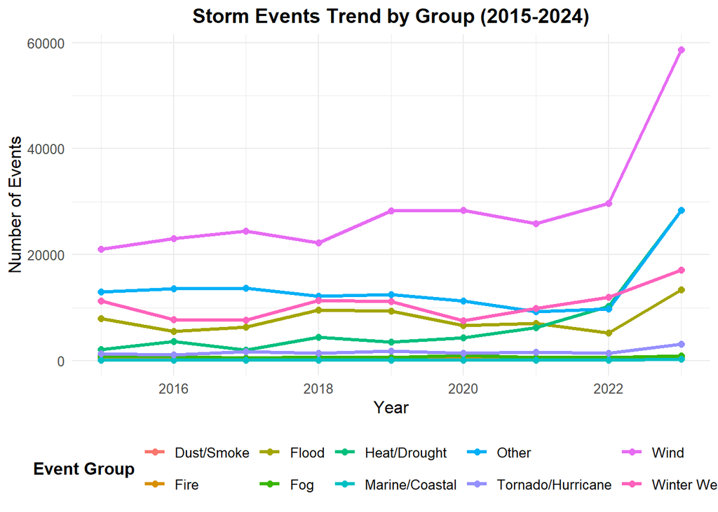

```r
# Line plot
ggplot(events_by_year_group, aes(x = YEAR, y = Event_Count, color = EVENT_GROUP)) +
  geom_line(size = 1.2) +
  geom_point(size = 2) +
  labs(title = "Storm Events Trend by Group (2015-2024)",
       x = "Year", y = "Number of Events",
       color = "Event Group") +
  theme_minimal() +
  theme(legend.position = "bottom",
        text = element_text(size = 12),
        legend.title = element_text(face = "bold"),
        plot.title = element_text(face = "bold", size = 14, hjust = 0.5))
```

Figure 1: line Plot

Table 1: Summary of fatalities by sex

```r
# Summary of fatalities by sex

fatalities_by_sex <- F_all %>%
  mutate(Year_Only = substr(FAT_YEARMONTH, 1, 4)) %>%
  filter(!is.na(FATALITY_SEX)) %>%  # Remove rows where FATALITY_SEX is NA
  group_by(Year_Only, FATALITY_SEX) %>%
  summarise(Fatality_Count = n(), .groups = "drop")%>%
  arrange(desc(Year_Only))

datatable(fatalities_by_sex,
          options = list(pageLength = 10),
          class = "display",
          filter = "top",
          caption = "Summary of fatalities by sex",
          escape = TRUE)
```

|  | Year_Only | FATALITY_SEX | Fatality_Count |
| --- | --- | --- | --- |
| 1 | 2024 | F | 297 |
| 2 | 2024 | M | 670 |
| 3 | 2023 | F | 257 |
| 4 | 2023 | M | 534 |
| 5 | 2022 | F | 232 |
| 6 | 2022 | M | 447 |
| 7 | 2021 | F | 284 |
| 8 | 2021 | M | 587 |
| 9 | 2020 | F | 149 |
| 10 | 2020 | M | 409 |

[output cut: 10 more lines]

```r
#Table Summary of Hazardous (Hurricane) Weather Fatalities(DEATHS_DIRECT + DEATHS_INDIRECT),
#Injuries (INJURIES_DIRECT + INJURIES_INDIRECT) , and Damage Costs(DAMAGE_PROPERTY, DAMAGE_CROP) Listed by State (STATE)

places_to_remove <- c(
  "VIRGIN ISLANDS", "PUERTO RICO", "ST LAWRENCE R", "LAKE ONTARIO",
  "LAKE ST CLAIR", "LAKE SUPERIOR", "HAWAII WATERS", "LAKE ERIE",
  "LAKE HURON", "LAKE MICHIGAN", "DISTRICT OF COLUMBIA", "E PACIFIC",
  "GUAM WATERS", "GULF OF ALASKA", "GULF OF MEXICO", "AMERICAN SAMOA",
  "ATLANTIC NORTH", "ATLANTIC SOUTH", "GUAM"
)

Storms_all <- D_all %>%  filter(!STATE %in% places_to_remove) %>%
  mutate(
    DAMAGE_PROPERTY_NUM = convert_damage(DAMAGE_PROPERTY),
    DAMAGE_CROP_NUM = convert_damage(DAMAGE_CROPS)
  )


#Summarize by State
summary_table_Hurricane <- Storms_all %>%
  group_by(STATE) %>%
  summarise(
    Total_Fatalities = sum(DEATHS_DIRECT + DEATHS_INDIRECT, na.rm = TRUE),
    Total_Injuries = sum(INJURIES_DIRECT + INJURIES_INDIRECT, na.rm = TRUE),
    Total_Property_Damage = sum(DAMAGE_PROPERTY_NUM, na.rm = TRUE),
    Total_Crop_Damage = sum(DAMAGE_CROP_NUM, na.rm = TRUE),
    .groups = "drop"
  )
datatable(summary_table_Hurricane,
          options = list(pageLength = 10),
          class = "display",
          filter = "top",
          caption = "Summary of Hazardous (Hurricane) Weather",
          escape = TRUE)
```

|  | STATE | Total_Fatalities | Total_Injuries | Total_Property_Damage | Total_Crop_Damage |
| --- | --- | --- | --- | --- | --- |
| 1 | ALABAMA | 161 | 522 | 499308650 | 2083700 |
| 2 | ALASKA | 36 | 20 | 123944340 | 1000 |
| 3 | ARIZONA | 3150 | 305 | 303807500 | 4780000 |
| 4 | ARKANSAS | 61 | 650 | 1008559500 | 60613800 |
| 5 | CALIFORNIA | 555 | 1276 | 22947583660 | 173628800 |
| 6 | COLORADO | 110 | 873 | 5559946630 | 34611300 |
| 7 | CONNECTICUT | 12 | 24 | 81820910 | 19000 |
| 8 | DELAWARE | 5 | 138 | 4241590 | 0 |
| 9 | FLORIDA | 585 | 622 | 34645399830 | 2901422700 |
| 10 | GEORGIA | 107 | 633 | 2251169770 | 3136484570 |

[output cut: 40 more lines]

Between 2015 and 2024, heavy snow events led to the following impacts: Minnesota recorded the highest fatalities at 9, New Mexico saw the most injuries with 72, Oregon experienced the greatest property damage at $159,154,000, and California had the highest crop damage at $2,000,000.

Table 4: Summary table for heavy snow data

```r
Snow_damage <- Snow_damage %>%
  mutate(
    DAMAGE_PROPERTY_NUM = convert_damage(DAMAGE_PROPERTY),
    DAMAGE_CROP_NUM = convert_damage(DAMAGE_CROPS)
  )

# Summary table for heavy snow data
#Summarize by State
summary_table_snow <- Snow_damage %>% filter(!STATE %in% places_to_remove) %>%
  group_by(STATE) %>%
  summarise(
    Total_Fatalities = sum(DEATHS_DIRECT + DEATHS_INDIRECT, na.rm = TRUE),
    Total_Injuries = sum(INJURIES_DIRECT + INJURIES_INDIRECT, na.rm = TRUE),
    Total_Property_Damage = sum(DAMAGE_PROPERTY_NUM, na.rm = TRUE),
    Total_Crop_Damage = sum(DAMAGE_CROP_NUM, na.rm = TRUE),
    .groups = "drop"
  )


datatable(summary_table_snow,
          options = list(),
          colnames = c("State", "Event", "Total Fatalities"),
          caption = "Summary for heavy snow data",
          filter = "top",
          escape = TRUE)
```

[interactive table not shown]

From 2015 to 2024, Tornado events resulted in the following impacts: Mississippi recorded the highest fatalities at 83 and the most crop damage at 42 million, while Texas saw the greatest number of injuries at 1,265 and the highest property damage at 2.3 Billion (Table 5).

Table 5: Summary table for Tornado from 2015 to 2024

```r
datatable(summary_table_Tornado,
          options = list(pageLength = 10),
          class = "display",
          filter = "top",       # You can change this to "bottom" or "none" if desired
          caption = "summary table for Tornado from 2015 to 2024",
          escape = TRUE)
```

|  | STATE | Total_Fatalities | Total_Injuries | Total_Property_Damage | Total_Crop_Damage |
| --- | --- | --- | --- | --- | --- |
| 1 | ALABAMA | 62 | 328 | 40494000 | 3000 |
| 2 | ARIZONA | 0 | 5 | 865000 | 0 |
| 3 | ARKANSAS | 15 | 279 | 886486000 | 2613000 |
| 4 | CALIFORNIA | 0 | 6 | 20712600 | 295000 |
| 5 | COLORADO | 0 | 5 | 4520500 | 100000 |
| 6 | CONNECTICUT | 0 | 0 | 1350500 | 5000 |
| 7 | DELAWARE | 2 | 1 | 200000 | 0 |
| 8 | FLORIDA | 4 | 49 | 115358640 | 12000 |
| 9 | GEORGIA | 43 | 479 | 382051000 | 7555000 |
| 10 | HAWAII | 0 | 0 | 0 | 0 |

[output cut: 39 more lines]

```r
#Top 5 Fatality-Causing Events by State (Excluding Zeros)

library(DT)

top5_fatal_events_by_state <- northeast_summary_Event %>%
  # Exclude zero fatalities
  filter(Total_Fatalities > 0) %>%

  # Group by state and rank within each group
  group_by(STATE) %>%
    slice_head(n = 5) %>%
  ungroup()

datatable(top5_fatal_events_by_state,
          options = list(pageLength = 10),
          class = "display",
          filter = "top",       # You can change this to "bottom" or "none" if desired
          caption = "Top 5 Fatality-Causing Events by State",
          escape = TRUE)
```

|  | STATE | EVENT_TYPE | Total_Fatalities | Total_Injuries | Total_Property_Damage | Total_Crop_Damage |
| --- | --- | --- | --- | --- | --- | --- |
| 1 | CONNECTICUT | Flood | 1 | 0 | 1398000 | 0 |
| 2 | CONNECTICUT | High Wind | 1 | 3 | 2496400 | 0 |
| 3 | CONNECTICUT | Strong Wind | 1 | 2 | 2250600 | 11000 |
| 4 | CONNECTICUT | Thunderstorm Wind | 6 | 10 | 8683900 | 1000 |
| 5 | CONNECTICUT | Tropical Storm | 1 | 0 | 54337800 | 0 |
| 6 | MAINE | Cold/Wind Chill | 2 | 2 | 0 | 0 |
| 7 | MAINE | Dense Fog | 1 | 0 | 0 | 0 |
| 8 | MAINE | Flood | 4 | 0 | 67775000 | 0 |
| 9 | MAINE | High Surf | 1 | 0 | 0 | 0 |
| 10 | MAINE | High Wind | 6 | 0 | 40000 | 0 |

[output cut: 33 more lines]

Cold/Wind Chill, blizzards, floods, thunderstorm winds, heavy snow, and excessive heat are the primary weather events responsible for the highest number of fatalities and injuries in the Northeastern states.

New York and Pennsylvania has highest fatalities happen in 10 years in Northeastern states (Fig. 23) however total injuries were highest for Pennsylvania and New Jersey (Fig. 24).

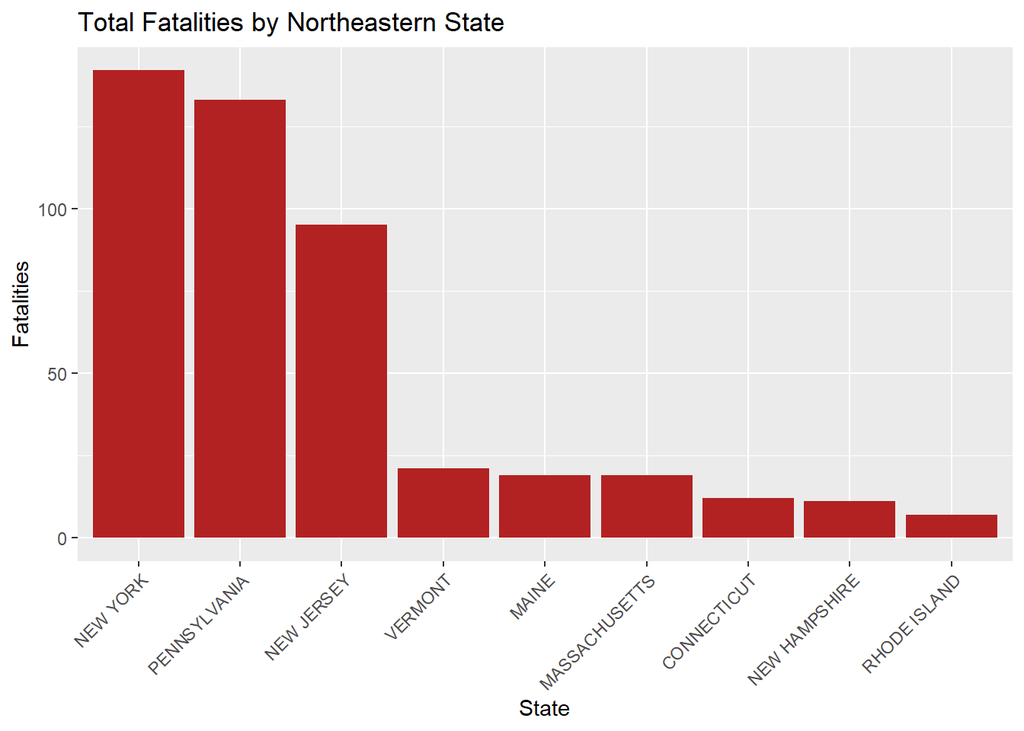

```r
#Bar Plot of Total Fatalities by State
ggplot(northeast_summary, aes(x = reorder(STATE, -Total_Fatalities), y = Total_Fatalities)) +
  geom_col(fill = "firebrick") +
  labs(title = "Total Fatalities by Northeastern State",
       x = "State", y = "Fatalities") + theme(axis.text.x = element_text(angle = 45, hjust = 1))
```

Fig 23. Total Fatalities by Northeastern State.

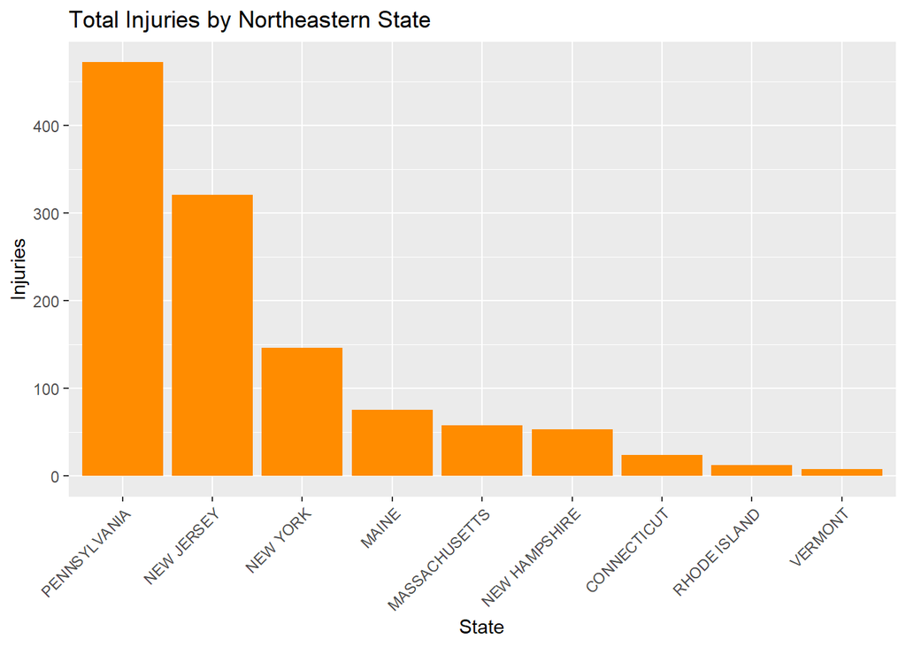

```r
#Bar Plot of Total Injuries by State
ggplot(northeast_summary, aes(x = reorder(STATE, -Total_Injuries), y = Total_Injuries)) +
  geom_col(fill = "darkorange") +
  labs(title = "Total Injuries by Northeastern State",
       x = "State", y = "Injuries") +
  theme(axis.text.x = element_text(angle = 45, hjust = 1))
```

Fig 24. Total Injuries by Northeastern State

Over the past 10 years, New York and Pennsylvania experienced the highest property damage among the Northeastern states (Fig. 25); however, New Hampshire and Maine reported the highest total crop damage.

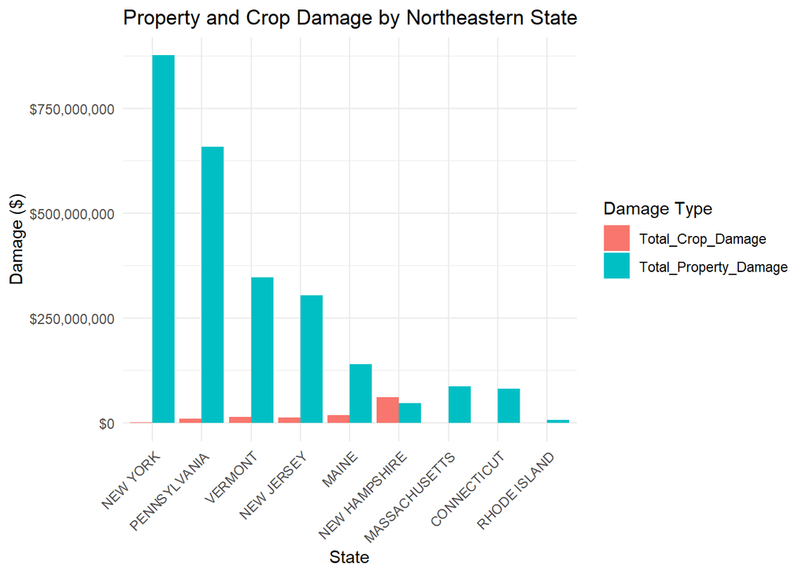

```r
#Side-by-Side Plot: Property vs Crop Damage
library(tidyr)

damage_long <- northeast_summary %>%
  select(STATE, Total_Property_Damage, Total_Crop_Damage) %>%
  pivot_longer(cols = starts_with("Total_"), names_to = "Damage_Type", values_to = "Damage_Value")

ggplot(damage_long, aes(x = reorder(STATE, -Damage_Value), y = Damage_Value, fill = Damage_Type)) +
  geom_col(position = "dodge") +
  labs(title = "Property and Crop Damage by Northeastern State",
       x = "State", y = "Damage ($)", fill = "Damage Type") +
  scale_y_continuous(labels = scales::dollar_format()) +
  theme_minimal() +
  theme(axis.text.x = element_text(angle = 45, hjust = 1))
```

Fig 25: Property and Crop Damage by Northeastern State

## 15 References

**Census Bureau (2021)**. *2020 Census Apportionment Results*. Available at: https://www.census.gov/data/tables/2020/dec/2020-apportionment-data.html (Accessed: 2025).

**Müller, K., Wickham, H., James, D.A., Falcon, S.** (2024). *RSQLite: SQLite Interface for R*. R package version 2.3.9, https://CRAN.R-project.org/package=RSQLite.

**National Centers for Environmental Protection (1999)**. *Storm Events Database*. Asheville, N.C: National Centers for Environmental Information, National Oceanic and Atmospheric Administration. Available at: https://www.ncdc.noaa.gov/stormevents/ftp.jsp (Accessed: 2025).

**R Special Interest Group on Databases (R-SIG-DB), Wickham, H., Müller, K.** (2024). *DBI: R Database Interface*. R package version 1.2.3, https://CRAN.R-project.org/package=DBI.

**Wickham, H.** (2016). *ggplot2: Elegant Graphics for Data Analysis*. Springer-Verlag New York.

**Wickham, H., François, R., Henry, L., Müller, K., Vaughan, D.** (2023). *dplyr: A Grammar of Data Manipulation*. R package version 1.1.4, https://CRAN.R-project.org/package=dplyr.

**Wickham, H., Hester, J., Bryan, J.** (2024). *readr: Read Rectangular Text Data*. R package version 2.1.5, https://CRAN.R-project.org/package=readr.

**Xie, Y., Cheng, J., Tan, X.** (2024). *DT: A Wrapper of the JavaScript Library ‘DataTables’*. R package version 0.33, https://CRAN.R-project.org/package=DT.